# ANOVA

## C:N

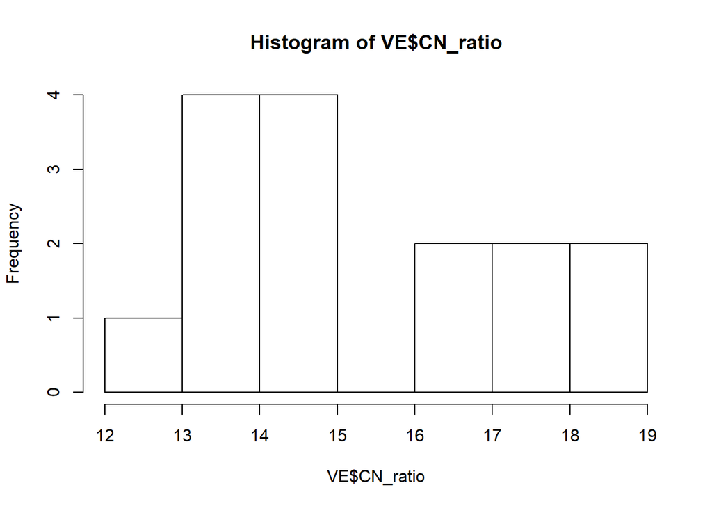

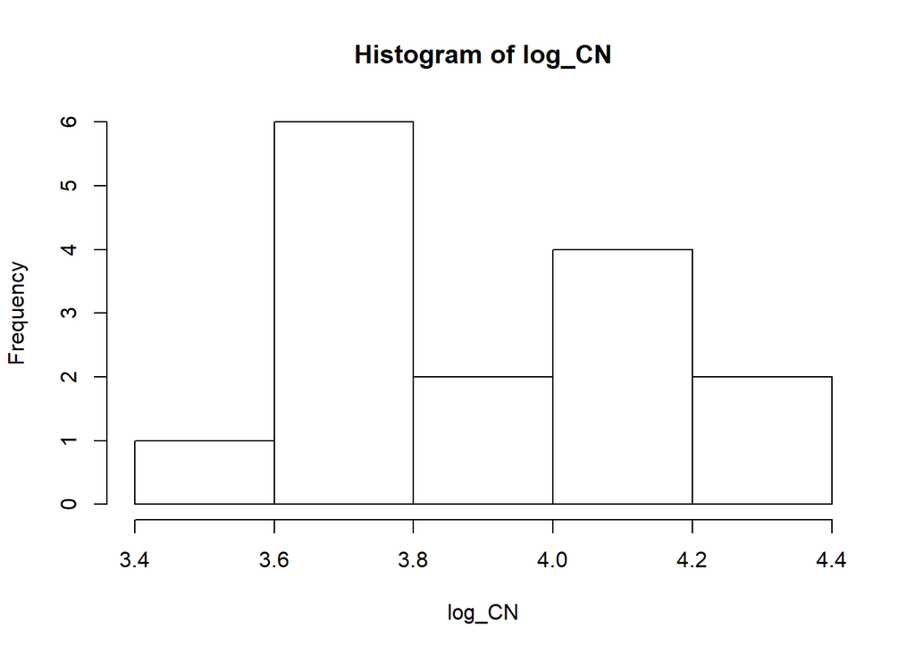

```
##             Df Sum Sq Mean Sq F value Pr(>F)
## Treatment    2 0.3466 0.17328   3.535 0.0621 .
## Residuals   12 0.5882 0.04902
## ---
## Signif. codes:  0 '***' 0.001 '**' 0.01 '*' 0.05 '.' 0.1 ' ' 1
```

```
## Tables of means
## Grand mean
##
## 3.901026
##
##  Treatment
##      16%    4%    8%
##     3.72 4.064 3.969
## rep 6.00 5.000 4.000
```

```
##   Tukey multiple comparisons of means
##     95% family-wise confidence level
##
## Fit: aov(formula = log_CN ~ Treatment, data = VE)
##
## $Treatment
##               diff         lwr       upr     p adj
## 4%-16%  0.34345393 -0.01421743 0.7011253 0.0601976
## 8%-16%  0.24816088 -0.13311806 0.6294398 0.2322241
## 8%-4%  -0.09529304 -0.49152974 0.3009437 0.8004661
```

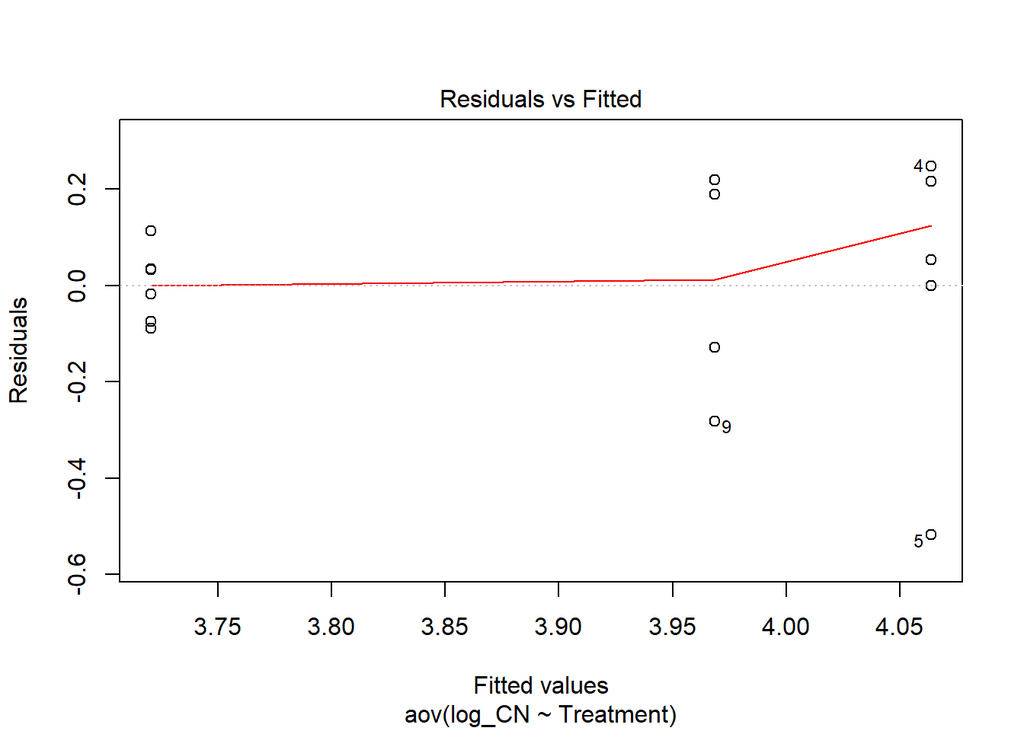

```
## Levene's Test for Homogeneity of Variance (center = median)
##       Df F value Pr(>F)
## group  2  1.8864 0.1939
##       12
```

# Table of results

**V.sieberiana Leaf Mass per Area (LMA)**

|  | Df | Sum Sq | Mean Sq | F value | Pr(>F) |
| --- | --- | --- | --- | --- | --- |
| Treatment | 2 | 0.30 | 0.15 | 22.47 | 0.0000 |
| Residuals | 14 | 0.09 | 0.01 |  |  |

**V.sieberiana Leaf 15N**

|  | Df | Sum Sq | Mean Sq | F value | Pr(>F) |
| --- | --- | --- | --- | --- | --- |
| Treatment | 2 | 0.15 | 0.07 | 0.87 | 0.4408 |
| Residuals | 14 | 1.20 | 0.09 |  |  |

**V.sieberiana Leaf 13C**

|  | Df | Sum Sq | Mean Sq | F value | Pr(>F) |
| --- | --- | --- | --- | --- | --- |
| Treatment | 2 | 1.34 | 0.67 | 1.50 | 0.2571 |
| Residuals | 14 | 6.24 | 0.45 |  |  |

**V.sieberiana Leaf N**

|  | Df | Sum Sq | Mean Sq | F value | Pr(>F) |
| --- | --- | --- | --- | --- | --- |
| Treatment | 2 | 0.01 | 0.01 | 1.29 | 0.3073 |
| Residuals | 14 | 0.06 | 0.00 |  |  |

**V.sieberiana Leaf C**

|  | Df | Sum Sq | Mean Sq | F value | Pr(>F) |
| --- | --- | --- | --- | --- | --- |
| Treatment | 2 | 11.22 | 5.61 | 2.60 | 0.1098 |
| Residuals | 14 | 30.24 | 2.16 |  |  |

**V.sieberiana Leaf C:N**

|  | Df | Sum Sq | Mean Sq | F value | Pr(>F) |
| --- | --- | --- | --- | --- | --- |
| Treatment | 2 | 0.13 | 0.07 | 0.83 | 0.4570 |
| Residuals | 14 | 1.13 | 0.08 |  |  |

### split

**V.erioloba Leaf Mass per Area (LMA)**

|  | Df | Sum Sq | Mean Sq | F value | Pr(>F) |
| --- | --- | --- | --- | --- | --- |
| Treatment | 2 | 674.73 | 337.36 | 2.62 | 0.1139 |
| Residuals | 12 | 1546.22 | 128.85 |  |  |

**V.erioloba Leaf 15N**

|  | Df | Sum Sq | Mean Sq | F value | Pr(>F) |
| --- | --- | --- | --- | --- | --- |
| Treatment | 2 | 0.48 | 0.24 | 3.86 | 0.0573 |
| Residuals | 10 | 0.62 | 0.06 |  |  |

**V.erioloba Leaf 13C**

|  | Df | Sum Sq | Mean Sq | F value | Pr(>F) |
| --- | --- | --- | --- | --- | --- |
| Treatment | 2 | 4.80 | 2.40 | 7.79 | 0.0068 |
| Residuals | 12 | 3.70 | 0.31 |  |  |

**V.erioloba Leaf N**

|  | Df | Sum Sq | Mean Sq | F value | Pr(>F) |
| --- | --- | --- | --- | --- | --- |
| Treatment | 2 | 0.88 | 0.44 | 3.45 | 0.0654 |
| Residuals | 12 | 1.53 | 0.13 |  |  |

**V.erioloba Leaf C**

|  | Df | Sum Sq | Mean Sq | F value | Pr(>F) |
| --- | --- | --- | --- | --- | --- |
| Treatment | 2 | 1.32 | 0.66 | 0.47 | 0.6381 |
| Residuals | 12 | 16.95 | 1.41 |  |  |

**V.erioloba Leaf C:N**

|  | Df | Sum Sq | Mean Sq | F value | Pr(>F) |
| --- | --- | --- | --- | --- | --- |
| Treatment | 2 | 0.35 | 0.17 | 3.53 | 0.0621 |
| Residuals | 12 | 0.59 | 0.05 |  |  |

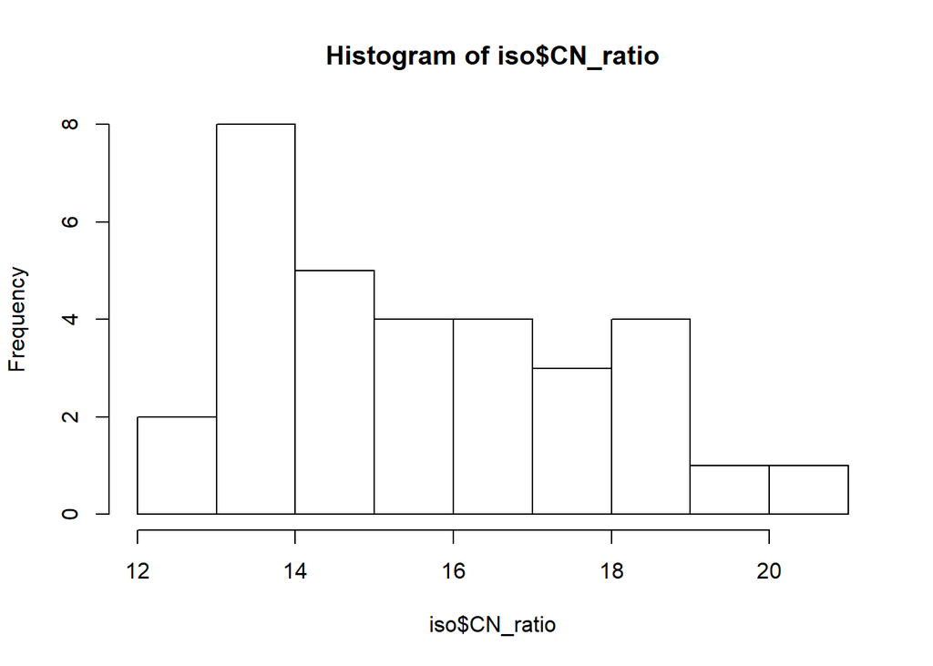

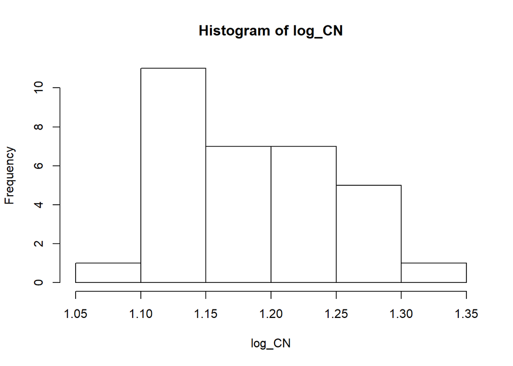

```
##             Df  Sum Sq  Mean Sq F value Pr(>F)
## Treatment    2 0.00929 0.004647   1.365  0.272
## Species      1 0.00330 0.003302   0.970  0.333
## Residuals   28 0.09531 0.003404
```

```
## Tables of means
## Grand mean
##
## 1.19107
##
##  Treatment
##        16%     4%     8%
##      1.176  1.216  1.184
## rep 11.000 10.000 11.000
##
##  Species
##        VE   VS
##      1.18  1.2
## rep 15.00 17.0
```

```
##   Tukey multiple comparisons of means
##     95% family-wise confidence level
##
## Fit: aov(formula = log_CN ~ Treatment + Species, data = iso)
##
## $Treatment
##                diff         lwr        upr     p adj
## 4%-16%  0.040108542 -0.02296610 0.10318318 0.2735594
## 8%-16%  0.008137777 -0.05341677 0.06969232 0.9428405
## 8%-4%  -0.031970764 -0.09504540 0.03110387 0.4322551
##
## $Species
##             diff         lwr        upr     p adj
## VS-VE 0.02010485 -0.02223034 0.06244003 0.3389909
```

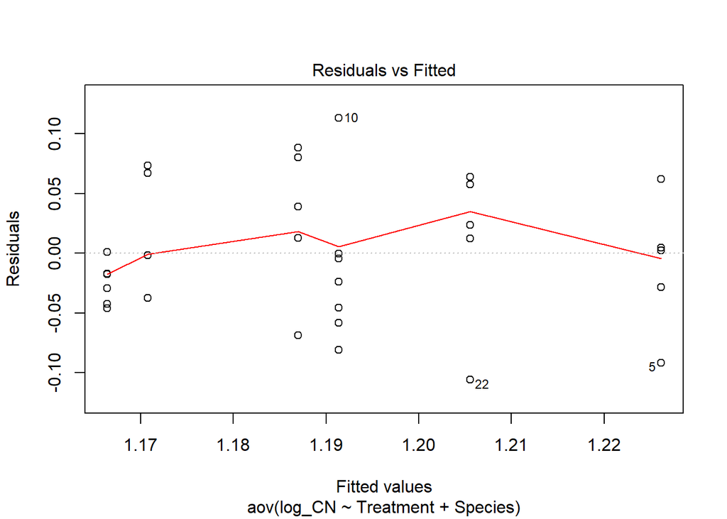

```
## Levene's Test for Homogeneity of Variance (center = median)
##       Df F value Pr(>F)
## group  5  0.5748 0.7187
##       26
```

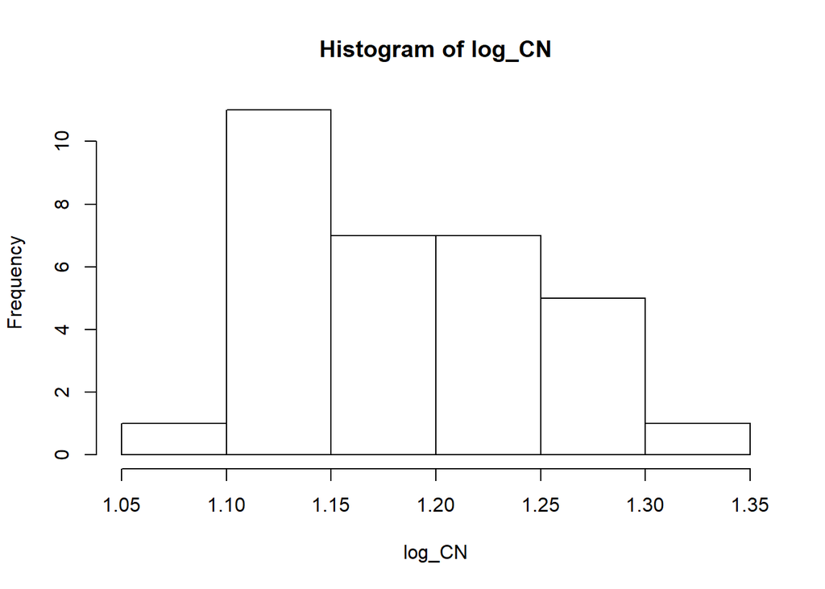

```
##             Df  Sum Sq  Mean Sq F value Pr(>F)
## Treatment    2 0.00929 0.004647   1.365  0.272
## Species      1 0.00330 0.003302   0.970  0.333
## Residuals   28 0.09531 0.003404
```

```
## Tables of means
## Grand mean
##
## 1.19107
##
##  Treatment
##        16%     4%     8%
##      1.176  1.216  1.184
## rep 11.000 10.000 11.000
##
##  Species
##        VE   VS
##      1.18  1.2
## rep 15.00 17.0
```

```
##   Tukey multiple comparisons of means
##     95% family-wise confidence level
##
## Fit: aov(formula = log_CN ~ Treatment + Species, data = iso)
##
## $Treatment
##                diff         lwr        upr     p adj
## 4%-16%  0.040108542 -0.02296610 0.10318318 0.2735594
## 8%-16%  0.008137777 -0.05341677 0.06969232 0.9428405
## 8%-4%  -0.031970764 -0.09504540 0.03110387 0.4322551
##
## $Species
##             diff         lwr        upr     p adj
## VS-VE 0.02010485 -0.02223034 0.06244003 0.3389909
```

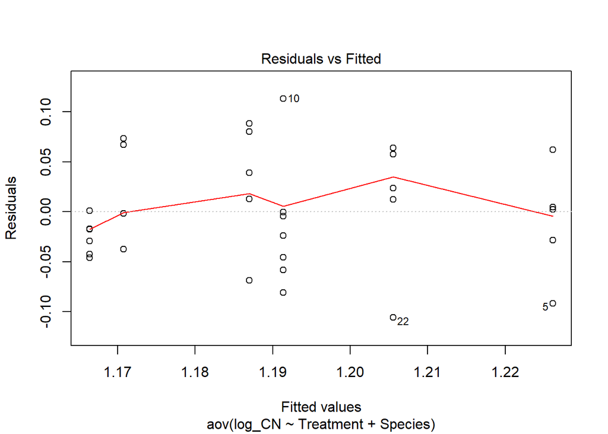

```
## Levene's Test for Homogeneity of Variance (center = median)
##       Df F value Pr(>F)
## group  5  0.5748 0.7187
##       26
```

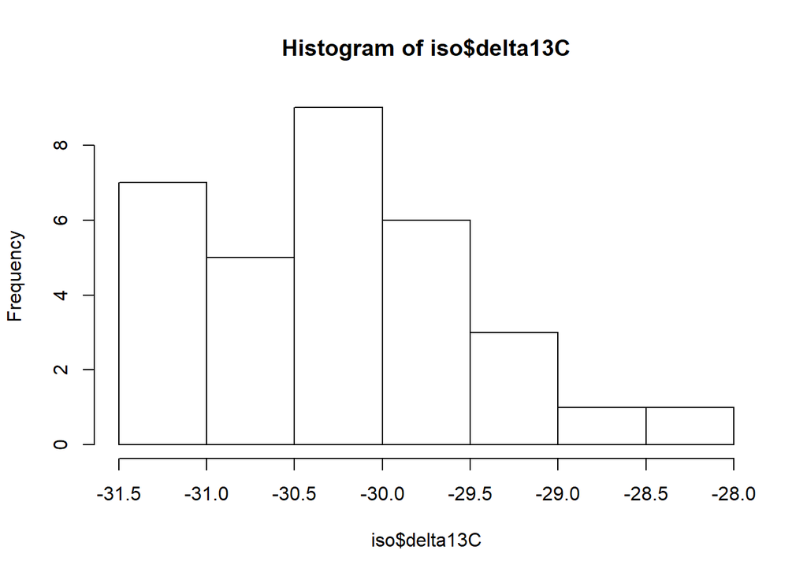

```
##             Df Sum Sq Mean Sq F value  Pr(>F)
## Treatment    2  4.786  2.3932   6.011 0.00673 **
## Species      1  0.550  0.5501   1.382 0.24971
## Residuals   28 11.148  0.3982
## ---
## Signif. codes:  0 '***' 0.001 '**' 0.01 '*' 0.05 '.' 0.1 ' ' 1
```

```
## Tables of means
## Grand mean
##
## -30.24733
##
##  Treatment
##        16%     4%     8%
##     -30.72 -29.76 -30.22
## rep  11.00  10.00  11.00
##
##  Species
##         VE     VS
##     -30.11 -30.37
## rep  15.00  17.00
```

```
##   Tukey multiple comparisons of means
##     95% family-wise confidence level
##
## Fit: aov(formula = delta13C ~ Treatment + Species, data = iso)
##
## $Treatment
##              diff        lwr      upr     p adj
## 4%-16%  0.9546861  0.2725029 1.636869 0.0047909
## 8%-16%  0.4956909 -0.1700518 1.161434 0.1745320
## 8%-4%  -0.4589952 -1.1411784 0.223188 0.2362700
##
## $Species
##             diff        lwr       upr     p adj
## VS-VE -0.2594959 -0.7173718 0.1983799 0.2554801
```

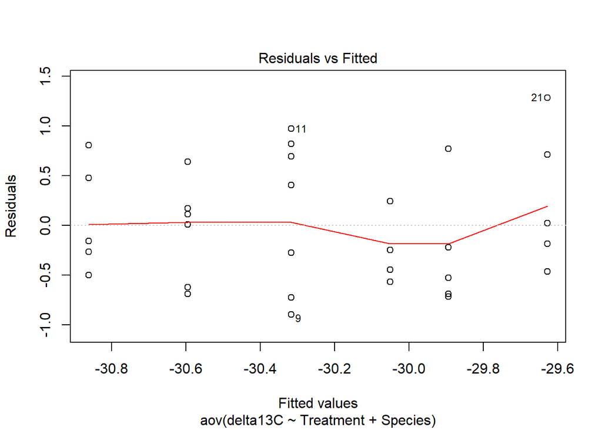

```
## Levene's Test for Homogeneity of Variance (center = median)
##       Df F value Pr(>F)
## group  5  0.5269 0.7538
##       26
```

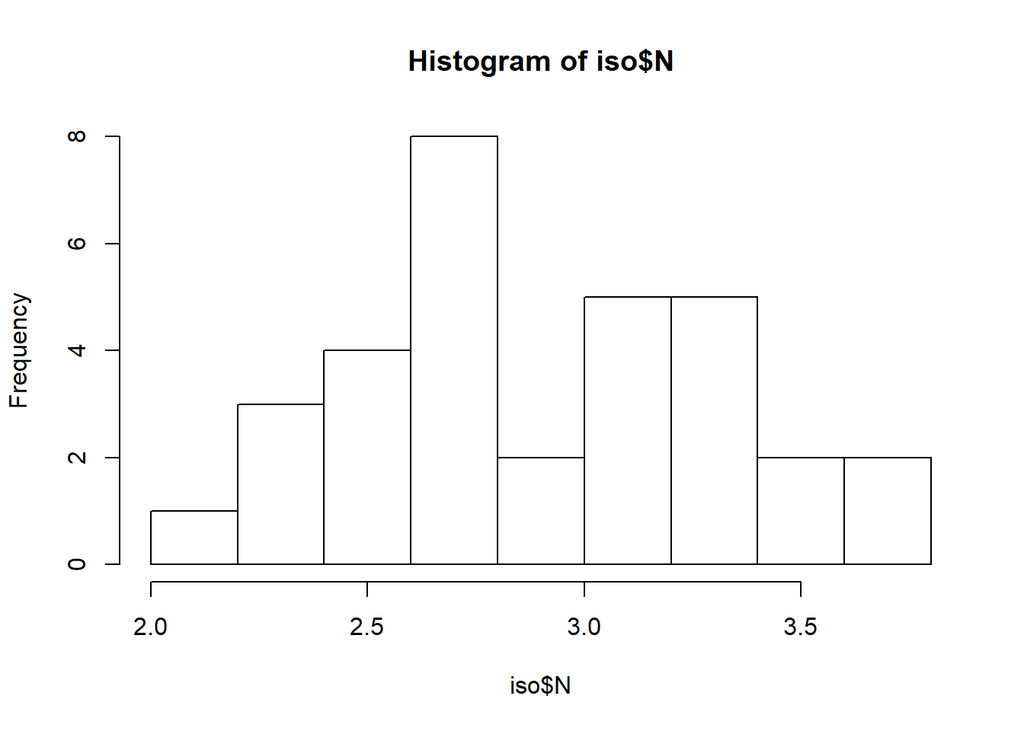

```
##             Df Sum Sq Mean Sq F value Pr(>F)
## Treatment    2  0.405  0.2026   1.103 0.3457
## Species      1  0.707  0.7066   3.848 0.0598 .
## Residuals   28  5.142  0.1836
## ---
## Signif. codes:  0 '***' 0.001 '**' 0.01 '*' 0.05 '.' 0.1 ' ' 1
```

```
## Tables of means
## Grand mean
##
## 2.905836
##
##  Treatment
##        16%     4%     8%
##      3.003  2.741  2.959
## rep 11.000 10.000 11.000
##
##  Species
##         VE     VS
##      3.062  2.768
## rep 15.000 17.000
```

```
##   Tukey multiple comparisons of means
##     95% family-wise confidence level
##
## Fit: aov(formula = N ~ Treatment + Species, data = iso)
##
## $Treatment
##               diff        lwr       upr     p adj
## 4%-16% -0.26164695 -0.7249270 0.2016331 0.3558435
## 8%-16% -0.04421973 -0.4963347 0.4078953 0.9682659
## 8%-4%   0.21742722 -0.2458528 0.6807073 0.4855816
##
## $Species
##             diff        lwr        upr     p adj
## VS-VE -0.2940843 -0.6050341 0.01686554 0.0628558
```

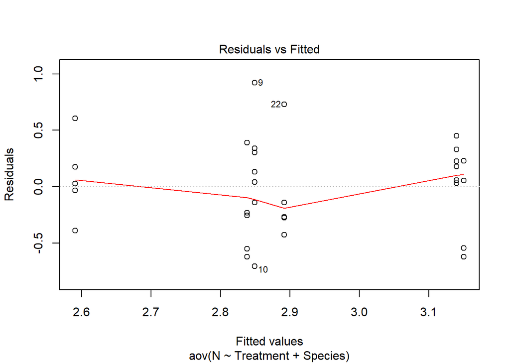

```
## Levene's Test for Homogeneity of Variance (center = median)
##       Df F value Pr(>F)
## group  5  0.5235 0.7563
##       26
```

### 13c and c:N

**Leaf 13C**

|  | Df | Sum Sq | Mean Sq | F value | Pr(>F) |
| --- | --- | --- | --- | --- | --- |
| Treatment | 2 | 4.79 | 2.39 | 6.01 | 0.0067 |
| Species | 1 | 0.55 | 0.55 | 1.38 | 0.2497 |
| Residuals | 28 | 11.15 | 0.40 |  |  |

**Leaf C:N ratio**

|  | Df | Sum Sq | Mean Sq | F value | Pr(>F) |
| --- | --- | --- | --- | --- | --- |
| Treatment | 2 | 0.01 | 0.00 | 1.37 | 0.2718 |
| Species | 1 | 0.00 | 0.00 | 0.97 | 0.3331 |
| Residuals | 28 | 0.10 | 0.00 |  |  |

**Leaf N**

|  | Df | Sum Sq | Mean Sq | F value | Pr(>F) |
| --- | --- | --- | --- | --- | --- |
| Treatment | 2 | 0.41 | 0.20 | 1.10 | 0.3457 |
| Species | 1 | 0.71 | 0.71 | 3.85 | 0.0598 |
| Residuals | 28 | 5.14 | 0.18 |  |  |

## growth

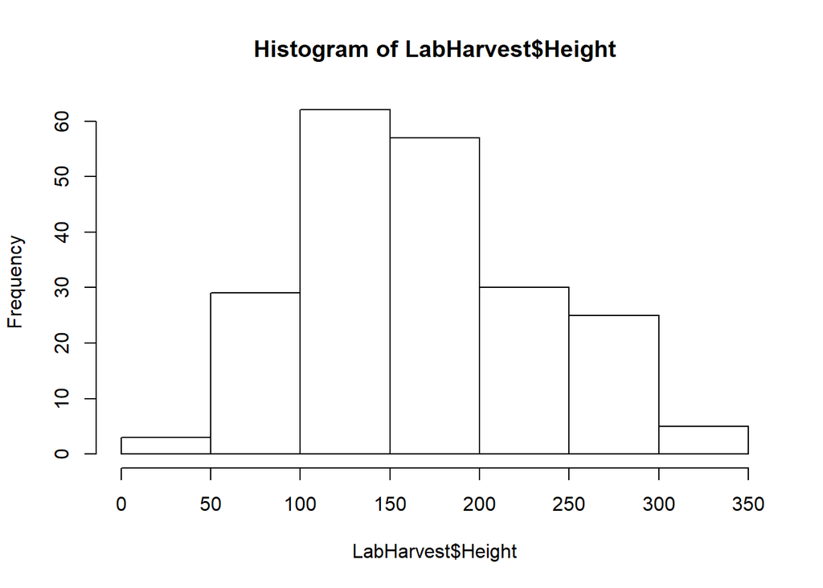

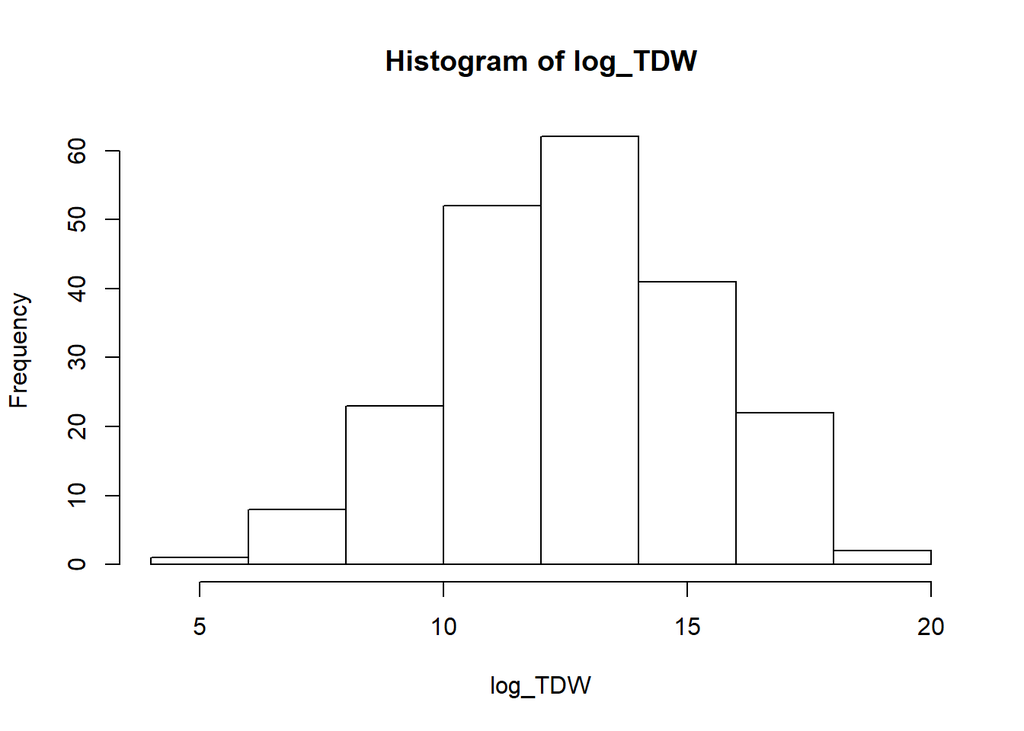

```
##                            Df Sum Sq Mean Sq F value Pr(>F)
## Treatment                   2   19.2     9.6   4.197 0.0164 *
## Species                     1  263.2   263.2 114.948 <2e-16 ***
## Harvest                     2  645.5   322.7 140.957 <2e-16 ***
## Treatment:Species           2   19.1     9.5   4.168 0.0169 *
## Treatment:Harvest           4   23.8     5.9   2.599 0.0376 *
## Species:Harvest             2   16.0     8.0   3.499 0.0322 *
## Treatment:Species:Harvest   4    8.2     2.1   0.900 0.4653
## Residuals                 193  441.9     2.3
## ---
## Signif. codes:  0 '***' 0.001 '**' 0.01 '*' 0.05 '.' 0.1 ' ' 1
```

```
##   Tukey multiple comparisons of means
##     95% family-wise confidence level
##
## Fit: aov(formula = log_TDW ~ Treatment * Species * Harvest, data = LabHarvest)
##
## $Treatment
##              diff         lwr       upr     p adj
## 4%-16% -0.1499793 -0.75006604 0.4501074 0.8254789
## 8%-16%  0.5527286 -0.05575139 1.1612085 0.0835076
## 8%-4%   0.7027079  0.10262115 1.3027946 0.0170627
##
## $Species
##           diff      lwr      upr p adj
## VS-VE 2.235129 1.823836 2.646422     0
##
## $Harvest
##           diff       lwr      upr    p adj
## H2-H1 3.037712 2.4177419 3.657681 0.00e+00
## H3-H1 4.175871 3.5756381 4.776104 0.00e+00
## H3-H2 1.138159 0.5451924 1.731126 3.02e-05
##
## $`Treatment:Species`
##                     diff         lwr       upr     p adj
## 4%:VE-16%:VE  -0.9303328 -1.97918736 0.1185218 0.1141903
## 8%:VE-16%:VE   0.1759493 -0.89685806 1.2487566 0.9970481
## 16%:VS-16%:VE  1.5287206  0.47986603 2.5775752 0.0005858
## 4%:VS-16%:VE   2.0584245  1.03017333 3.0866757 0.0000005
## 8%:VS-16%:VE   2.3246788  1.28988679 3.3594708 0.0000000
## 8%:VE-4%:VE    1.1062821  0.04093132 2.1716328 0.0367511
## 16%:VS-4%:VE   2.4590534  1.41782693 3.5002798 0.0000000
## 4%:VS-4%:VE    2.9887573  1.96828823 4.0092263 0.0000000
## 8%:VS-4%:VE    3.2550116  2.22795213 4.2820710 0.0000000
## 16%:VS-8%:VE   1.3527713  0.28742060 2.4181221 0.0044158
## 4%:VS-8%:VE    1.8824752  0.83740263 2.9275478 0.0000080
## 8%:VS-8%:VE    2.1487295  1.09722072 3.2002383 0.0000003
## 4%:VS-16%:VS   0.5297039 -0.49076515 1.5501729 0.6684008
## 8%:VS-16%:VS   0.7959582 -0.23110126 1.8230176 0.2285274
## 8%:VS-4%:VS    0.2662543 -0.73975543 1.2722641 0.9734853
##
## $`Treatment:Harvest`
```

[output cut: 196 more lines]

```
## 4%:VE:H3-16%:VE:H3  -1.12886159 -3.313729690  1.0560065 0.9331162
## 8%:VE:H3-16%:VE:H3  -0.23507246 -2.469044851  1.9988999 1.0000000
## 16%:VS:H3-16%:VE:H3  2.17603279  0.033593350  4.3184722 0.0421291
## 4%:VS:H3-16%:VE:H3   2.54725397  0.474506098  4.6200018 0.0028907
## 8%:VS:H3-16%:VE:H3   1.62517948 -0.447568393  3.6979274 0.3390220
## 8%:VE:H3-4%:VE:H3    0.89378913 -1.340183260  3.1277615 0.9945742
## 16%:VS:H3-4%:VE:H3   3.30489438  1.162454942  5.4473338 0.0000218
## 4%:VS:H3-4%:VE:H3    3.67611556  1.603367690  5.7488634 0.0000003
## 8%:VS:H3-4%:VE:H3    2.75404107  0.681293199  4.8267889 0.0006801
## 16%:VS:H3-8%:VE:H3   2.41110525  0.218611060  4.6035994 0.0157871
## 4%:VS:H3-8%:VE:H3    2.78232643  0.657881148  4.9067717 0.0009037
## 8%:VS:H3-8%:VE:H3    1.86025194 -0.264193344  3.9846972 0.1677801
## 4%:VS:H3-16%:VS:H3   0.37122119 -1.656753636  2.3991960 0.9999999
## 8%:VS:H3-16%:VS:H3  -0.55085331 -2.578828128  1.4771215 0.9999615
## 8%:VS:H3-4%:VS:H3   -0.92207449 -2.876279928  1.0321309 0.9701218
```

```
## Tables of means
## Grand mean
##
## 12.65436
##
##  Treatment
##       16%    4%    8%
##     12.53 12.38 13.08
## rep 69.00 73.00 69.00
##
##  Species
##         VE     VS
##      11.49  13.72
## rep 101.00 110.00
##
##  Harvest
##        H1    H2    H3
##     10.13 13.17 14.31
## rep 65.00 68.00 78.00
##
##  Treatment:Species
##          Species
## Treatment VE    VS
##       16% 11.75 13.28
##       rep 34.00 35.00
##       4%  10.82 13.81
##       rep 35.00 38.00
##       8%  11.93 14.07
##       rep 32.00 37.00
##
##  Treatment:Harvest
##          Harvest
## Treatment H1     H2     H3
##       16%  9.611 13.001 14.536
##       rep 21.000 23.000 25.000
##       4%   9.691 12.747 14.233
##       rep 22.000 24.000 27.000
##       8%  11.092 13.801 14.175
##       rep 22.000 21.000 26.000
##
```

[output cut: 26 more lines]

```
##       4%  11.313 14.054
##       rep 12.000 12.000
##       8%  12.260 15.147
##       rep 10.000 11.000
##
## , , Harvest = H3
##
##          Species
## Treatment VE     VS
##       16% 13.419 15.595
##       rep 12.000 13.000
##       4%  12.291 15.967
##       rep 12.000 15.000
##       8%  13.184 15.045
##       rep 11.000 15.000
```

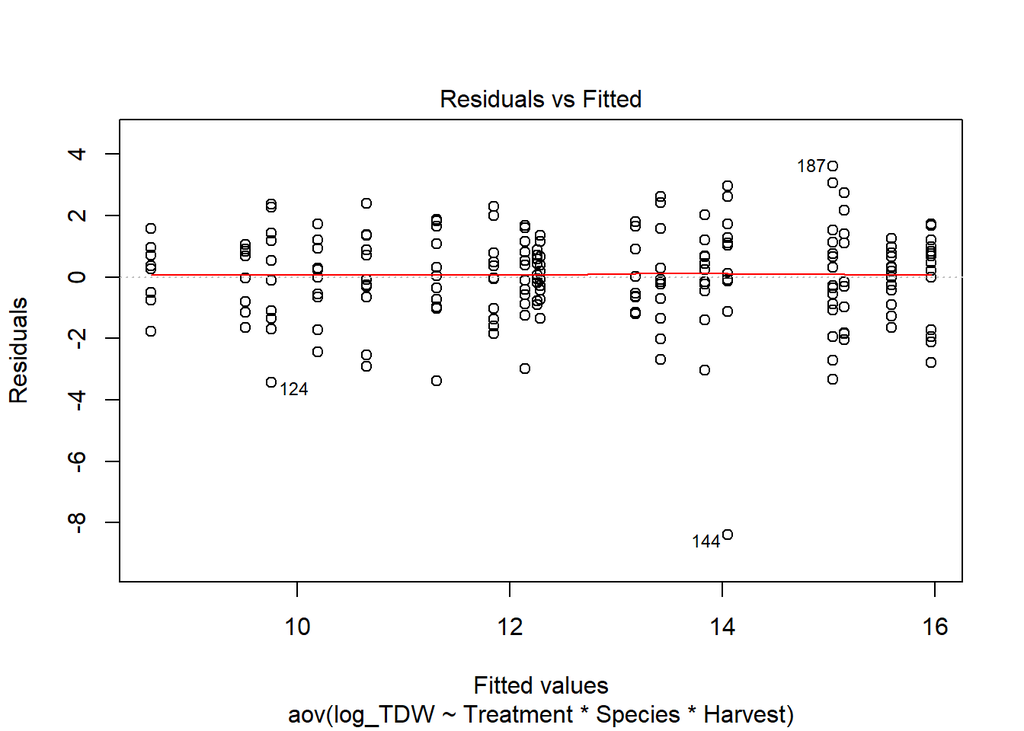

```
## Levene's Test for Homogeneity of Variance (center = median)
##        Df F value Pr(>F)
## group  17  1.1074 0.3489
##       193
```

## Below ground

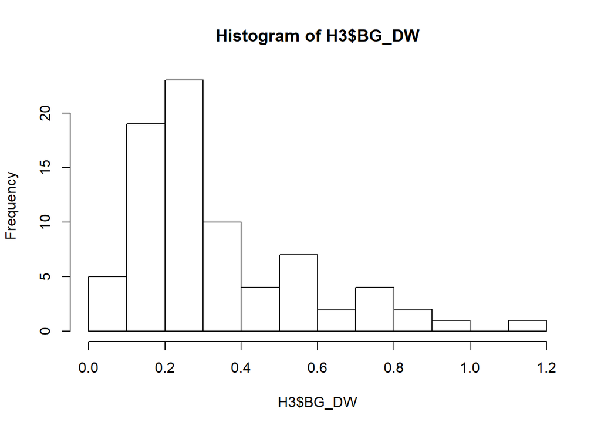

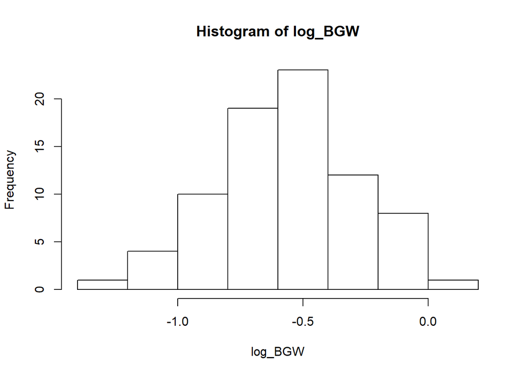

```
##             Df Sum Sq Mean Sq F value   Pr(>F)
## Treatment    2  0.075  0.0374    0.78    0.462
## Species      1  2.744  2.7442   57.24 8.55e-11 ***
## Residuals   74  3.548  0.0479
## ---
## Signif. codes:  0 '***' 0.001 '**' 0.01 '*' 0.05 '.' 0.1 ' ' 1
```

```
##   Tukey multiple comparisons of means
##     95% family-wise confidence level
##
## Fit: aov(formula = log_BGW ~ Treatment + Species, data = H3)
##
## $Treatment
##               diff        lwr        upr     p adj
## 4%-16%  0.03324032 -0.1121112 0.17859182 0.8483409
## 8%-16% -0.04180723 -0.1884964 0.10488198 0.7748784
## 8%-4%  -0.07504754 -0.2189404 0.06884528 0.4293837
##
## $Species
##            diff       lwr       upr p adj
## VS-VE 0.3767149 0.2773946 0.4760352     0
```

```
## Tables of means
## Grand mean
##
## -0.5603151
##
##  Treatment
##         16%      4%      8%
##     -0.5579 -0.5246 -0.5997
## rep 25.0000 27.0000 26.0000
##
##  Species
##         VE      VS
##     -0.768 -0.3913
## rep 35.000 43.0000
```

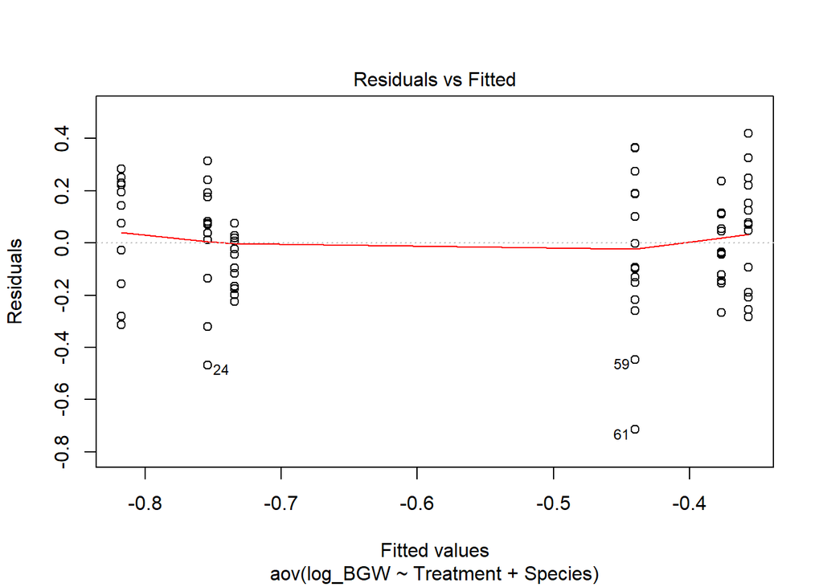

```
## Levene's Test for Homogeneity of Variance (center = median)
##       Df F value  Pr(>F)
## group  5   2.052 0.08147 .
##       72
## ---
## Signif. codes:  0 '***' 0.001 '**' 0.01 '*' 0.05 '.' 0.1 ' ' 1
```

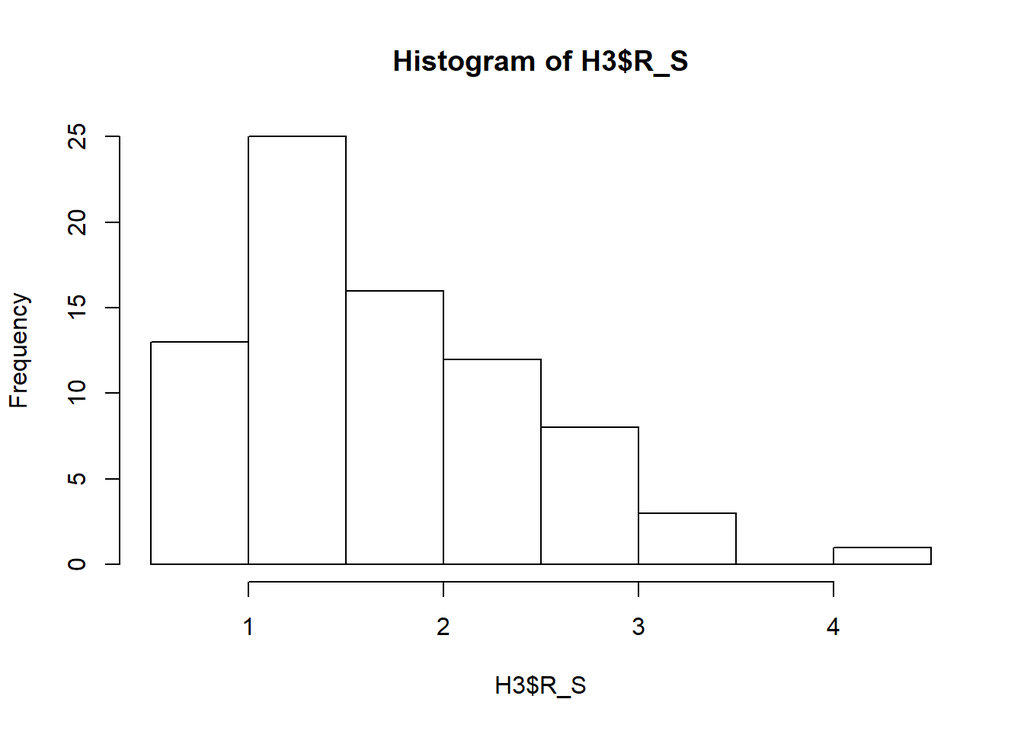

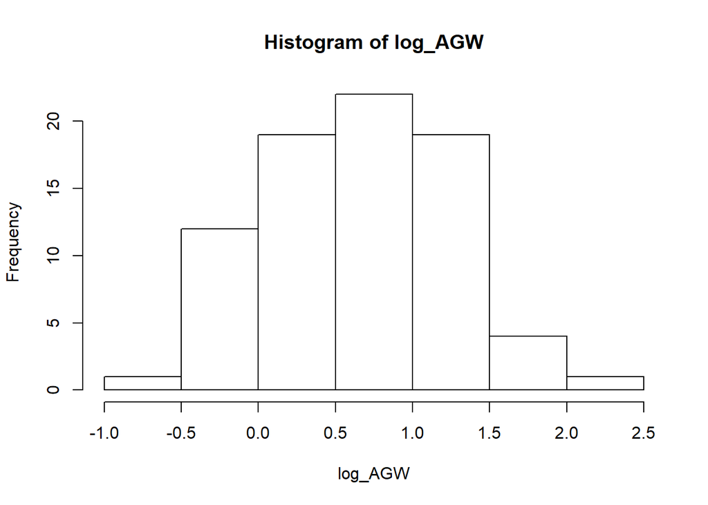

```
##             Df Sum Sq Mean Sq F value Pr(>F)
## Treatment    2  0.373   0.186   1.445  0.242
## Species      1 17.839  17.839 138.313 <2e-16 ***
## Residuals   74  9.544   0.129
## ---
## Signif. codes:  0 '***' 0.001 '**' 0.01 '*' 0.05 '.' 0.1 ' ' 1
```

```
##   Tukey multiple comparisons of means
##     95% family-wise confidence level
##
## Fit: aov(formula = log_AGW ~ Treatment + Species, data = H3)
##
## $Treatment
##               diff        lwr        upr     p adj
## 4%-16% -0.16642097 -0.4048281 0.07198614 0.2236886
## 8%-16% -0.05866713 -0.2992684 0.18193410 0.8295204
## 8%-4%   0.10775385 -0.1282607 0.34376841 0.5220354
##
## $Species
##             diff       lwr        upr p adj
## VS-VE -0.9604789 -1.123385 -0.7975727     0
```

```
## Tables of means
## Grand mean
##
## 0.6306278
##
##  Treatment
##         16%      4%      8%
##      0.7078  0.5414  0.6491
## rep 25.0000 27.0000 26.0000
##
##  Species
##        VE      VS
##      1.16  0.1996
## rep 35.00 43.0000
```

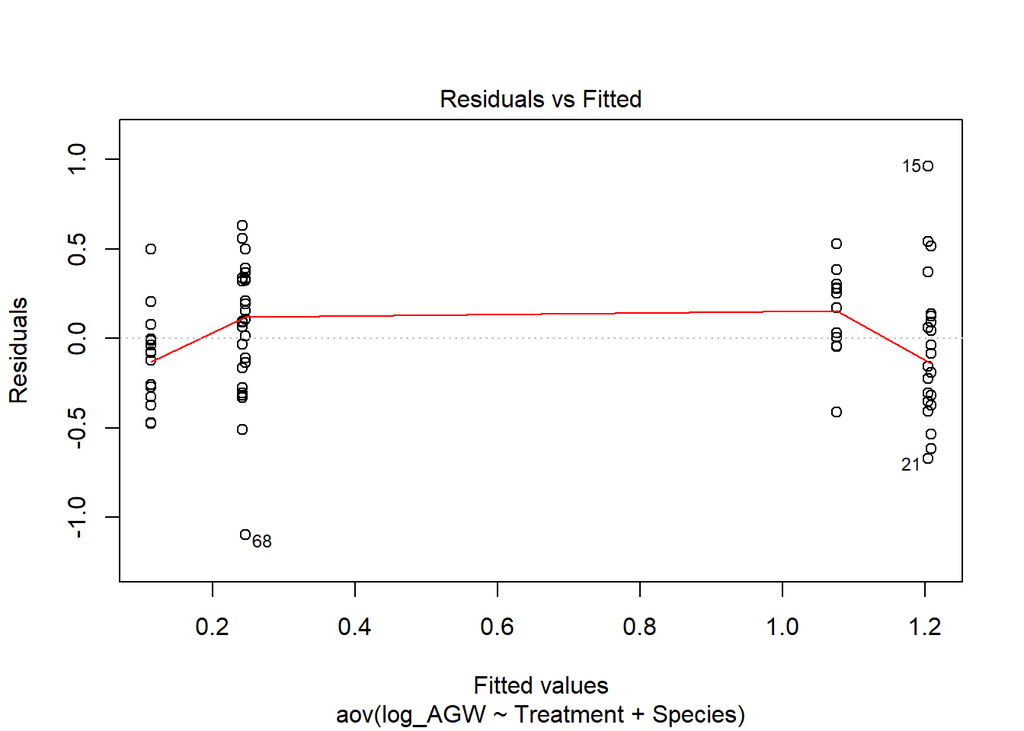

```
## Levene's Test for Homogeneity of Variance (center = median)
##       Df F value Pr(>F)
## group  5  0.6912 0.6317
##       72
```

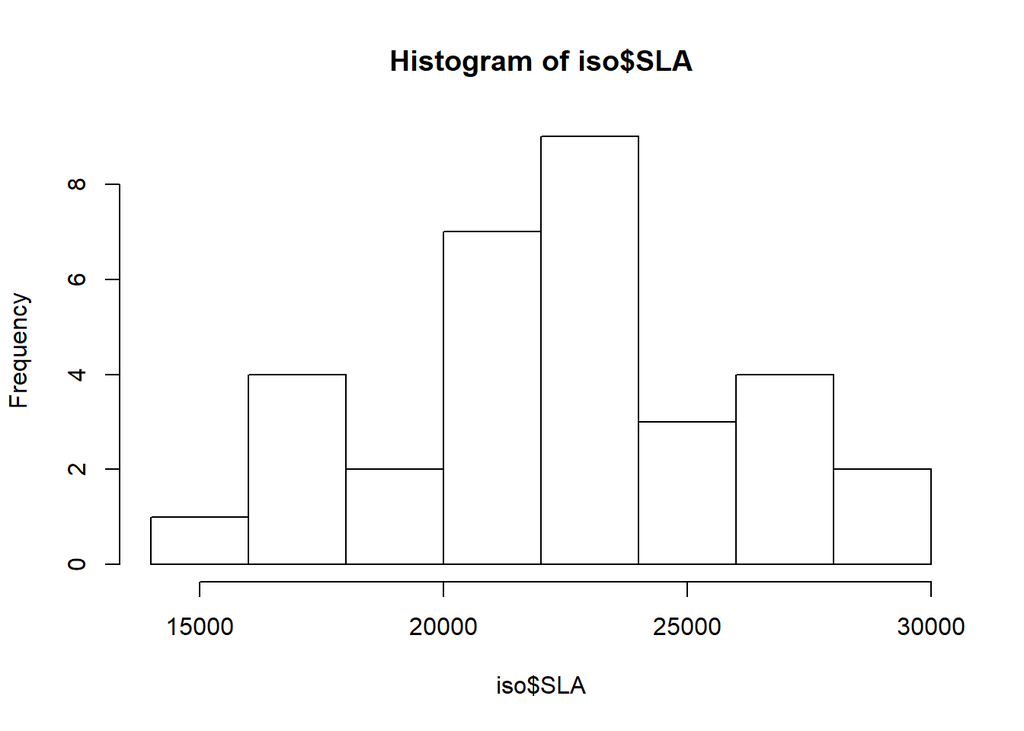

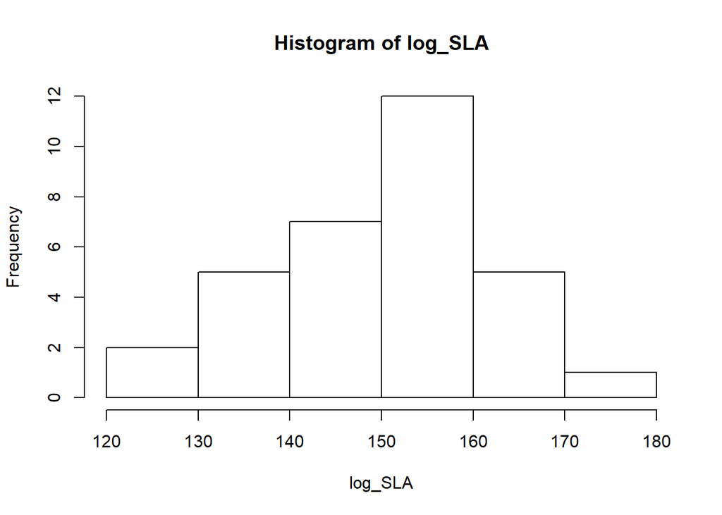

```
##             Df Sum Sq Mean Sq F value Pr(>F)
## Treatment    2    202  101.17   0.670  0.520
## Species      1     52   52.14   0.345  0.562
## Residuals   28   4230  151.06
```

```
##   Tukey multiple comparisons of means
##     95% family-wise confidence level
##
## Fit: aov(formula = log_SLA ~ Treatment + Species, data = iso)
##
## $Treatment
##           diff        lwr      upr     p adj
## 4%-16% 2.10936 -11.178388 15.39711 0.9187194
## 8%-16% 5.98456  -6.982954 18.95207 0.4969884
## 8%-4%  3.87520  -9.412548 17.16295 0.7528692
##
## $Species
##           diff       lwr      upr     p adj
## VS-VE 2.526211 -6.392418 11.44484 0.5664112
```

```
## Tables of means
## Grand mean
##
## 149.5716
##
##  Treatment
##       16%  4%    8%
##     146.9 149 152.8
## rep  11.0  10  11.0
##
##  Species
##        VE    VS
##     148.2 150.8
## rep  15.0  17.0
```

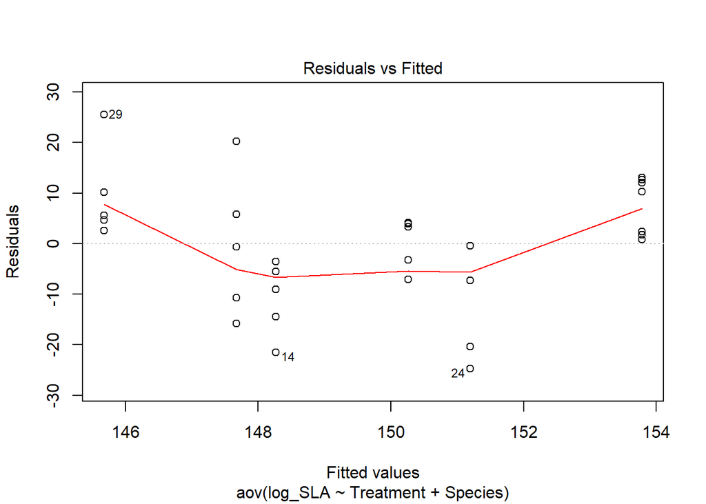

```
## Levene's Test for Homogeneity of Variance (center = median)
##       Df F value Pr(>F)
## group  5  1.2187 0.3284
##       26
```

**Belowground dry weight (grams)**

[output not shown]

**Root: Shoot ratio**

[output not shown]

**Leaf Mass per Area**

|  | Df | Sum Sq | Mean Sq | F value | Pr(>F) |
| --- | --- | --- | --- | --- | --- |
| Treatment | 2 | 202.34 | 101.17 | 0.67 | 0.5199 |
| Species | 1 | 52.14 | 52.14 | 0.35 | 0.5616 |
| Residuals | 28 | 4229.72 | 151.06 |  |  |

## break

**Nodule Count**

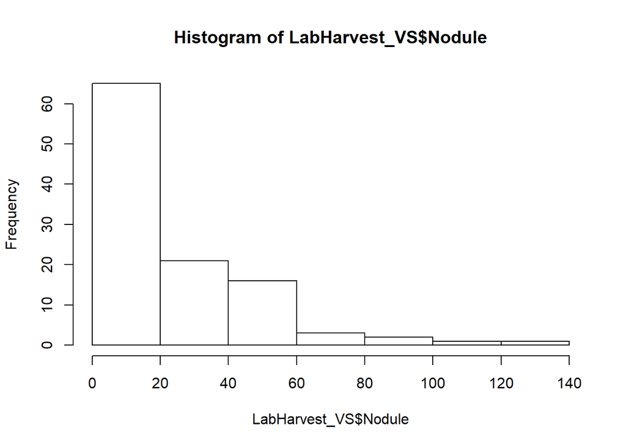

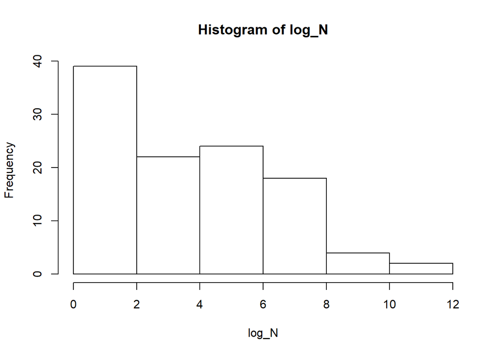

Fit: aov(formula = log_N ~ Treatment + Harvest, data = LabHarvest_VS)

$Treatment diff lwr upr p adj 8%-4% 1.1597570 0.1246078 2.194906 0.0241096 16%-4% 1.6209005 0.5628657 2.678935 0.0012206 16%-8% 0.4611436 -0.6036215 1.525909 0.5598383

$Harvest diff lwr upr p adj H2-H1 4.136992 3.0336170 5.240366 0.0000000 H3-H1 5.340068 4.3028253 6.377312 0.0000000 H3-H2 1.203077 0.1658337 2.240320 0.0186956

Tables of means Grand mean

3.545198

Treatment 4% 8% 16% 2.646 3.806 4.267 rep 38.000 37.000 34.000

Harvest H1 H2 H3 0.1861 4.323 5.526 rep 33.0000 33.000 43.000

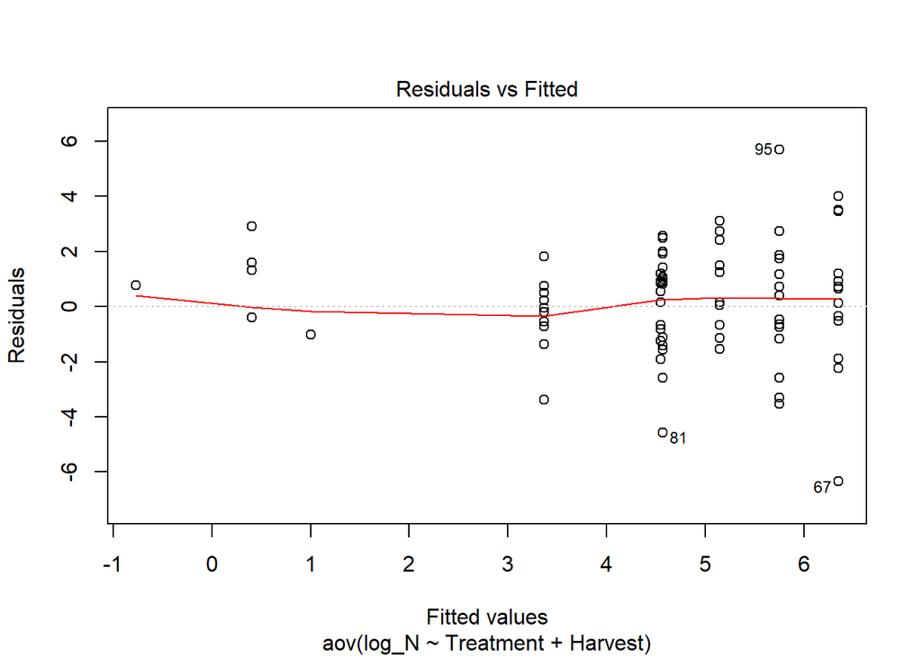

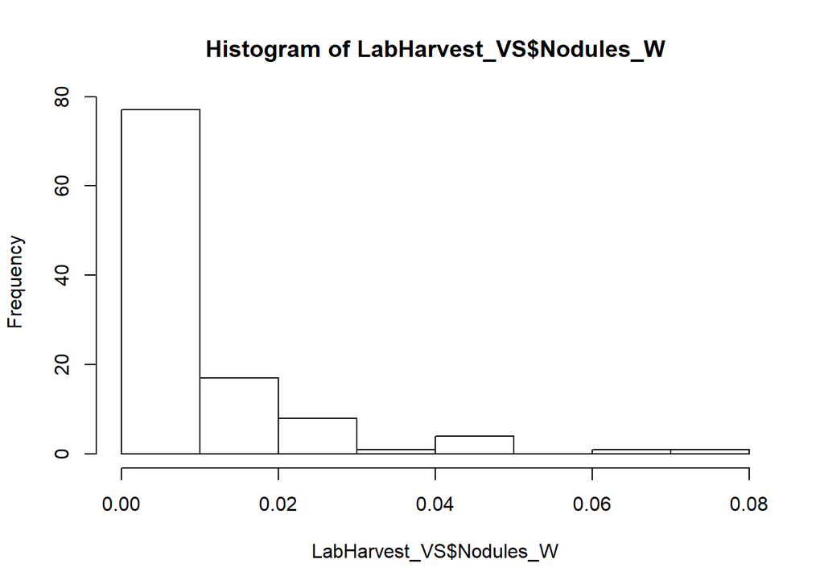

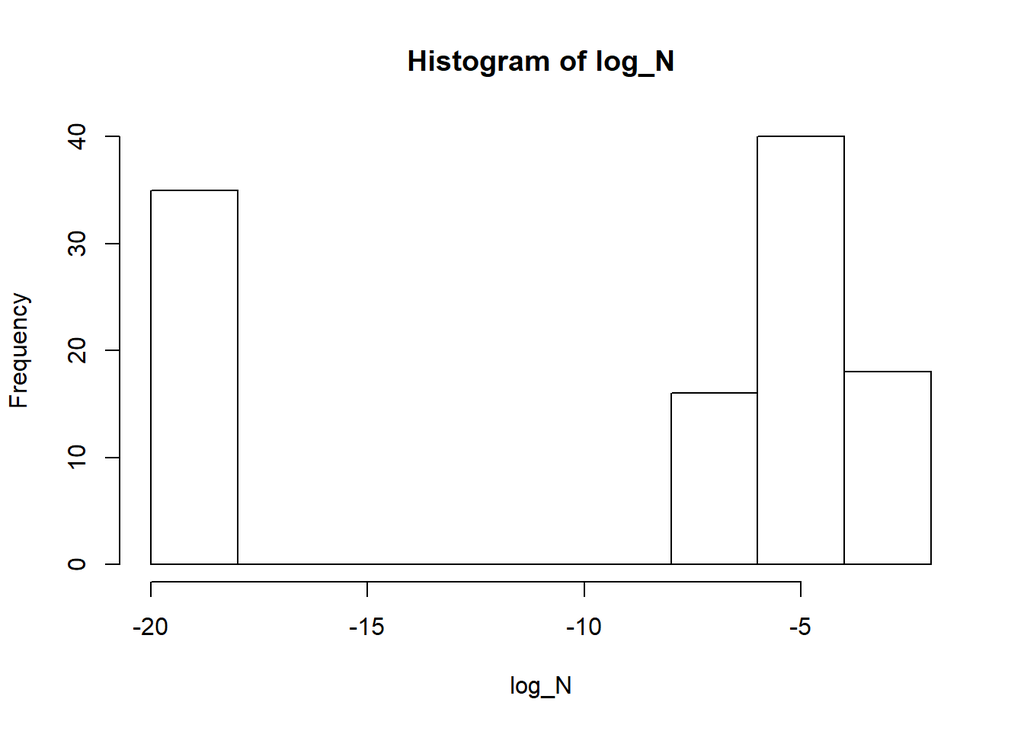

Fit: aov(formula = log_N ~ Treatment + Harvest, data = LabHarvest_VS)

$Treatment diff lwr upr p adj 8%-4% 2.365858 0.4673484 4.2643683 0.0104648 16%-4% 1.077745 -0.8627381 3.0182284 0.3870062 16%-8% -1.288113 -3.2409401 0.6647137 0.2638999

$Harvest diff lwr upr p adj H2-H1 11.2690377 9.245399 13.292676 0.00000 H3-H1 11.8001609 9.897811 13.702511 0.00000 H3-H2 0.5311231 -1.371227 2.433473 0.78492

Tables of means Grand mean

-9.26152

Treatment 4% 8% 16% -10.4 -8.035 -9.323 rep 38.0 37.000 34.000

Harvest H1 H2 H3 -17.33 -6.059 -5.528 rep 33.00 33.000 43.000

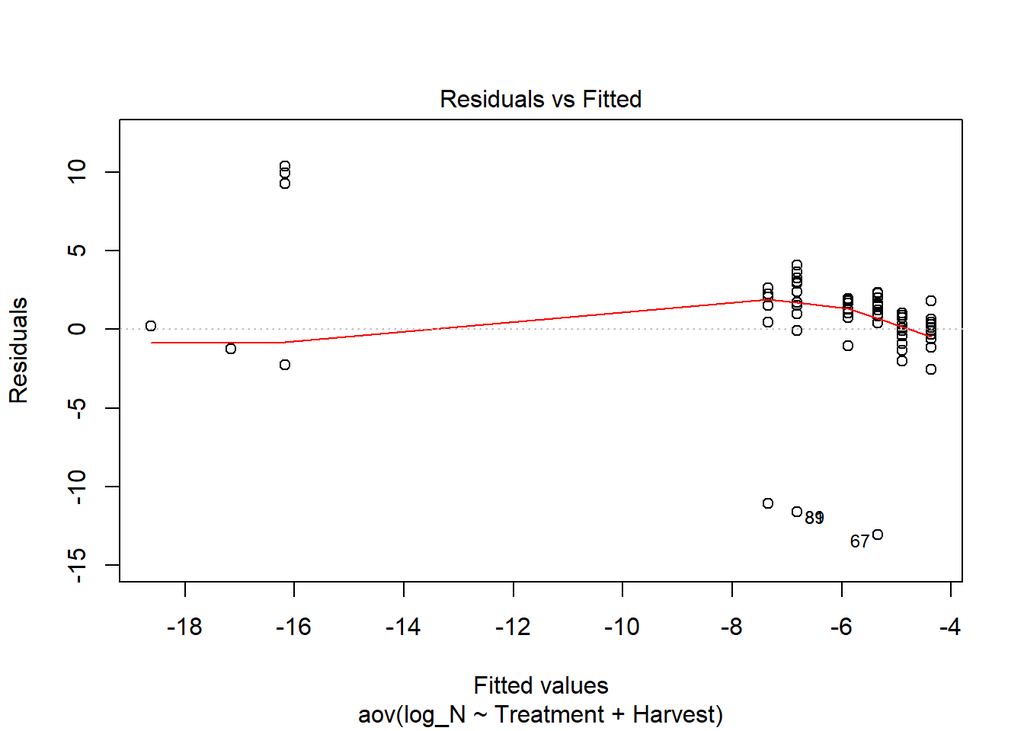

Levene’s Test for Homogeneity of Variance (center = median) Df F value Pr(>F)  
group 8 4.1975 0.0002299 *** 100  
— Signif. codes: 0 ‘**’ 0.001 ’**’ 0.01 ’’ 0.05 ‘.’ 0.1 ‘’ 1 **Biological Nitrogen Fixation**

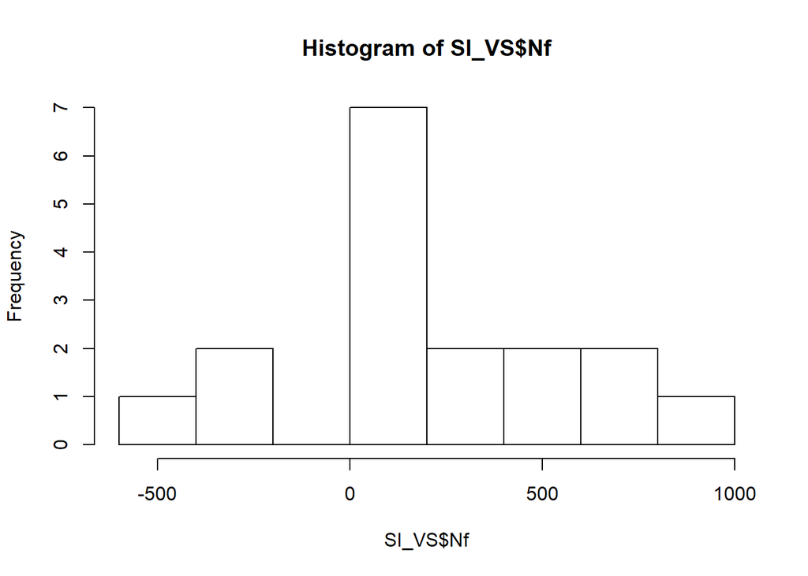

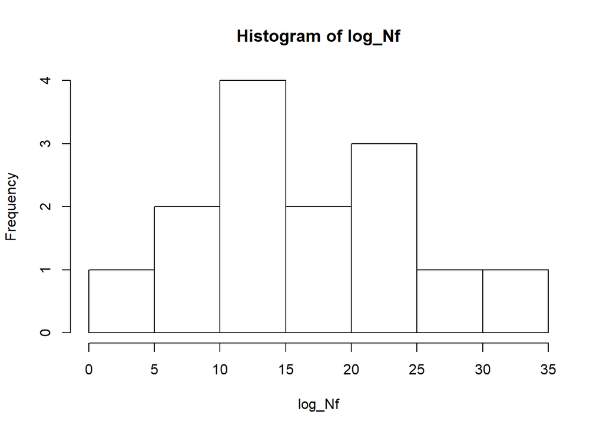

Df Sum Sq Mean Sq F value Pr(>F)  
Treatment 2 734.5 367.3 30.7 3.15e-05 *** Residuals 11 131.6 12.0  
— Signif. codes: 0 ‘**’ 0.001 ’**’ 0.01 ’’ 0.05 ‘.’ 0.1 ‘’ 1 3 observations deleted due to missingness Tukey multiple comparisons of means 95% family-wise confidence level

Fit: aov(formula = log_Nf ~ Treatment, data = SI_VS)

$Treatment diff lwr upr p adj 4%-16% -5.686448 -13.501646 2.12875 0.1670278 8%-16% 12.398866 6.929367 17.86836 0.0002028 8%-4% 18.085314 10.595894 25.57473 0.0001167

Tables of means Grand mean

16.69545

Treatment 16% 4% 8% 11.31 5.622 23.71 rep 5.00 2.000 7.00

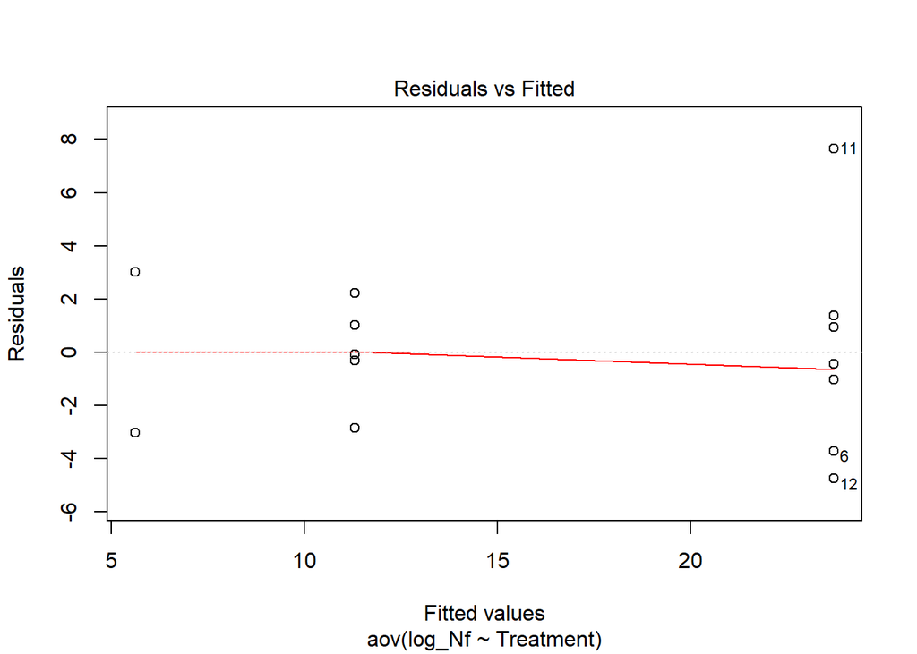

Levene’s Test for Homogeneity of Variance (center = median) Df F value Pr(>F) group 2 0.8297 0.4617 11

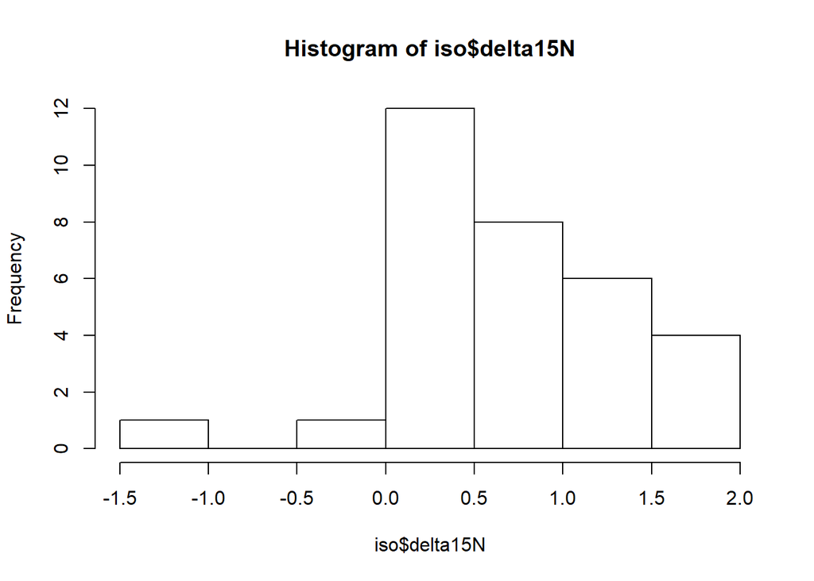

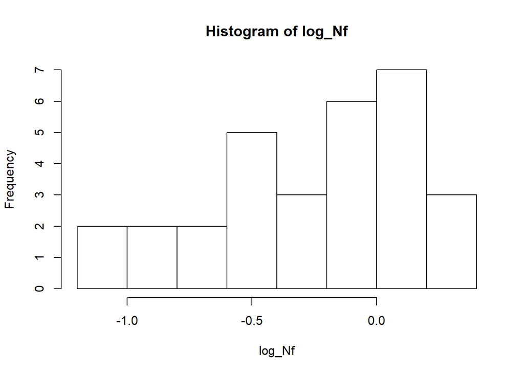

Df Sum Sq Mean Sq F value Pr(>F)  
Treatment 2 0.2362 0.1181 1.192 0.319538  
Species 1 1.9645 1.9645 19.838 0.000142 *** Residuals 26 2.5746 0.0990  
— Signif. codes: 0 ‘**’ 0.001 ’**’ 0.01 ’’ 0.05 ‘.’ 0.1 ‘’ 1 2 observations deleted due to missingness Tukey multiple comparisons of means 95% family-wise confidence level

Fit: aov(formula = log_Nf ~ Treatment + Species, data = iso)

$Treatment diff lwr upr p adj 4%-16% -0.20321187 -0.5448708 0.1384470 0.3176267 8%-16% -0.04062969 -0.3920904 0.3108310 0.9556088 8%-4% 0.16258218 -0.1966994 0.5218638 0.5079933

$Species diff lwr upr p adj VS-VE 0.4955161 0.2571965 0.7338357 0.0002282

Tables of means Grand mean

-0.2570797

Treatment 16% 4% 8% -0.1772 -0.3804 -0.2178 rep 11.0000 10.0000 9.0000

Species VE VS -0.5379 -0.04236 rep 13.0000 17.00000

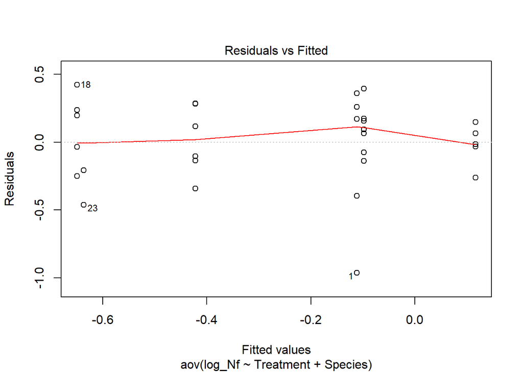

Levene’s Test for Homogeneity of Variance (center = median) Df F value Pr(>F) group 5 1.1995 0.3392 24

**Nodule Count**

|  | Df | Sum Sq | Mean Sq | F value | Pr(>F) |
| --- | --- | --- | --- | --- | --- |
| Treatment | 2 | 50.95 | 25.47 | 7.17 | 0.0012 |
| Harvest | 2 | 561.58 | 280.79 | 79.03 | 0.0000 |
| Residuals | 104 | 369.52 | 3.55 |  |  |

**Nodule Weight (grams)**

|  | Df | Sum Sq | Mean Sq | F value | Pr(>F) |
| --- | --- | --- | --- | --- | --- |
| Treatment | 2 | 105.12 | 52.56 | 4.40 | 0.0147 |
| Harvest | 2 | 3088.13 | 1544.07 | 129.19 | 0.0000 |
| Residuals | 104 | 1242.96 | 11.95 |  |  |

**Leaf 15N**

|  | Df | Sum Sq | Mean Sq | F value | Pr(>F) |
| --- | --- | --- | --- | --- | --- |
| Treatment | 2 | 0.24 | 0.12 | 1.19 | 0.3195 |
| Species | 1 | 1.96 | 1.96 | 19.84 | 0.0001 |
| Residuals | 26 | 2.57 | 0.10 |  |  |

**Biological Nitrogen Fixation**

|  | Df | Sum Sq | Mean Sq | F value | Pr(>F) |
| --- | --- | --- | --- | --- | --- |
| Treatment | 2 | 734.51 | 367.25 | 30.70 | 0.0000 |
| Residuals | 11 | 131.57 | 11.96 |  |  |

## break

```r
stargazer(N.aov, type = "html",
          digits = 3,
          star.cutoffs = c(0.05, 0.01, 0.001),
          digit.separator = "")
```

% Error: Unrecognized object type.

**Looking at the LICOR data**

**LSA (mm2) VS**

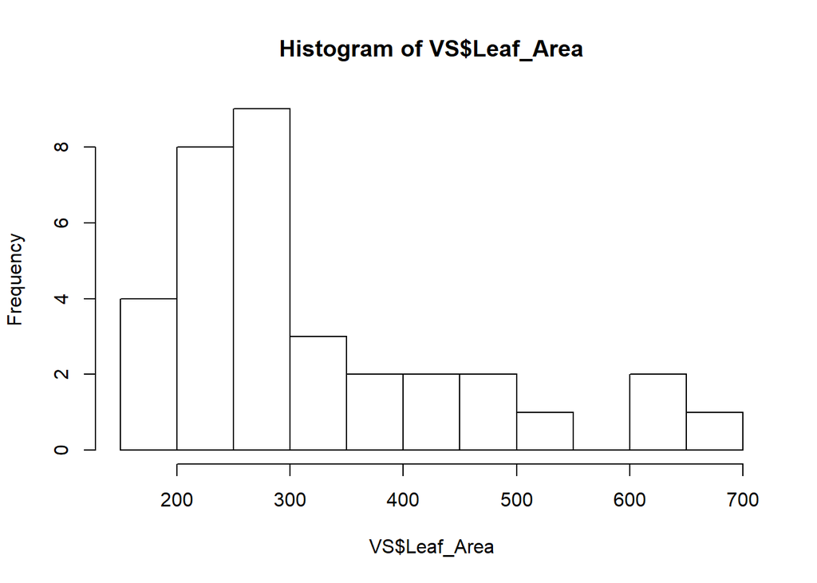

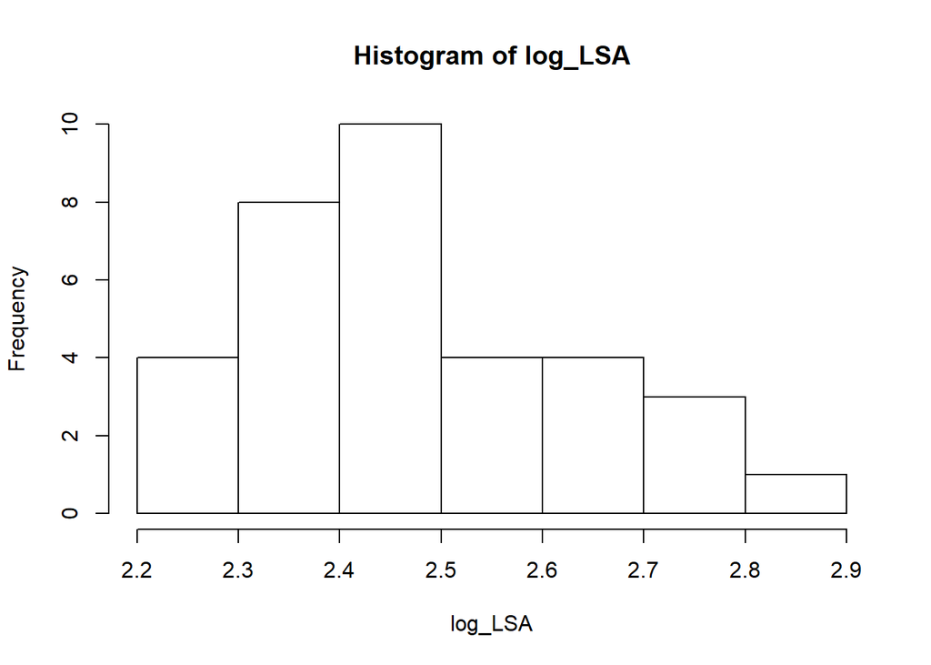

Df Sum Sq Mean Sq F value Pr(>F)  
Treatment 2 0.1558 0.07792 3.909 0.0314 * Harvest 2 0.1010 0.05051 2.534 0.0968 . Residuals 29 0.5780 0.01993  
— Signif. codes: 0 ‘**’ 0.001 ’**’ 0.01 ’’ 0.05 ‘.’ 0.1 ‘’ 1 Tukey multiple comparisons of means 95% family-wise confidence level

Fit: aov(formula = log_LSA ~ Treatment + Harvest, data = VS)

$Treatment diff lwr upr p adj 8%-4% 0.09019213 -0.0521479 0.23253217 0.2766966 16%-4% -0.07803984 -0.2273273 0.07124765 0.4114934 16%-8% -0.16823198 -0.3175195 -0.01894449 0.0246768

$Harvest diff lwr upr p adj H2-H1 0.10264388 -0.03575973 0.2410475 0.1772611 H3-H1 0.13189785 -0.03011078 0.2939065 0.1276134 H3-H2 0.02925398 -0.12338871 0.1818967 0.8843303

Tables of means Grand mean

2.479328

Treatment 4% 8% 16% 2.47 2.561 2.392 rep 12.00 12.000 10.000

Harvest H1 H2 H3 2.403 2.506 2.535 rep 11.000 15.000 8.000

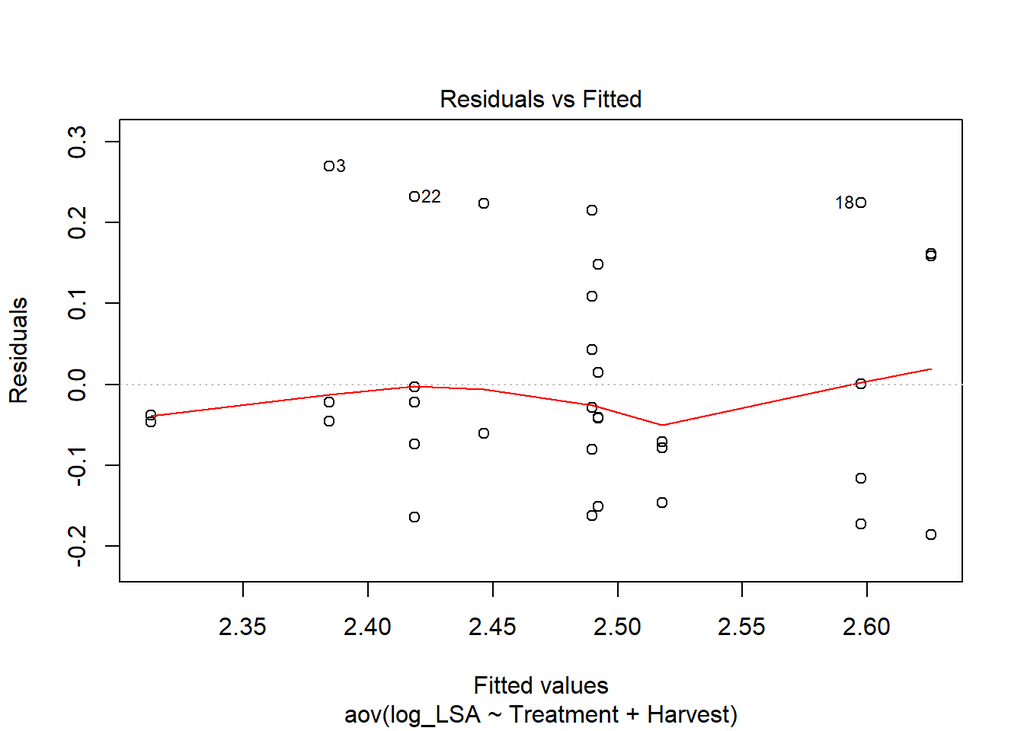

Levene’s Test for Homogeneity of Variance (center = median) Df F value Pr(>F) group 8 0.6269 0.7475 25  
**LSA (mm2) VE**

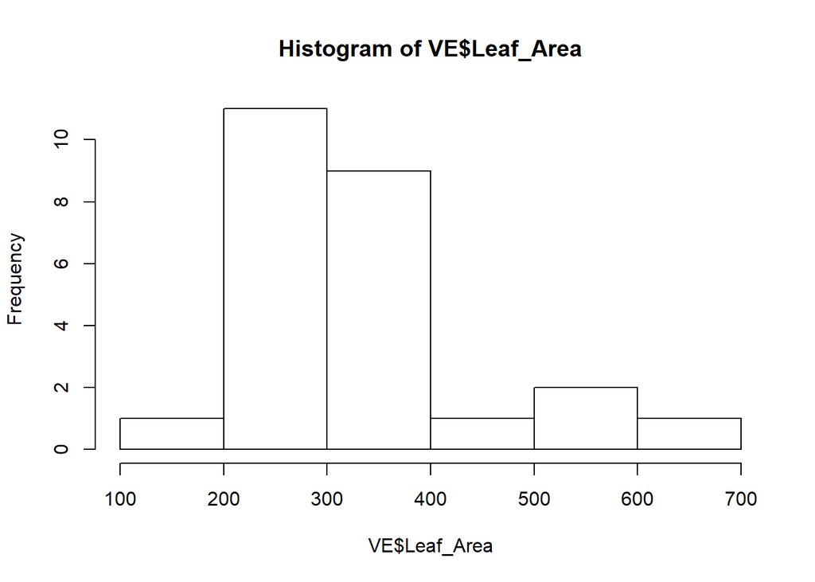

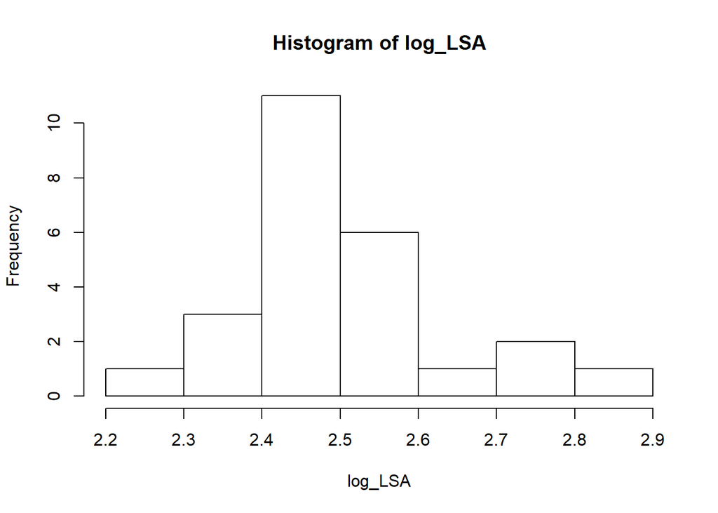

Df Sum Sq Mean Sq F value Pr(>F) Treatment 2 0.0040 0.002009 0.101 0.904 Harvest 1 0.0237 0.023735 1.198 0.286 Residuals 21 0.4161 0.019814  
Tukey multiple comparisons of means 95% family-wise confidence level

Tables of means Grand mean

2.499625

Treatment 4% 8% 16% 2.479 2.509 2.506 rep 7.000 10.000 8.000

Harvest H2 H3 2.527 2.465 rep 14.000 11.000

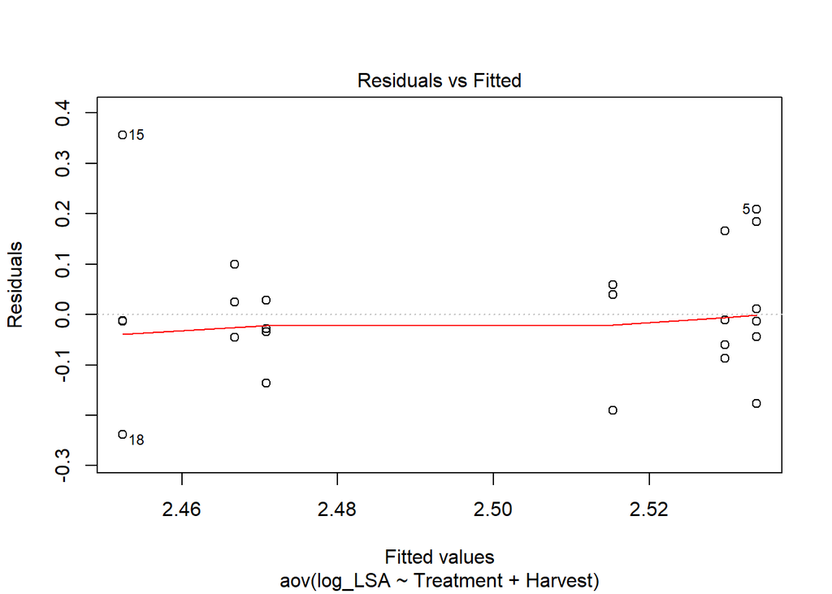

Levene’s Test for Homogeneity of Variance (center = median) Df F value Pr(>F) group 5 0.5586 0.7303 19  
**Ci (umol mol) VS**

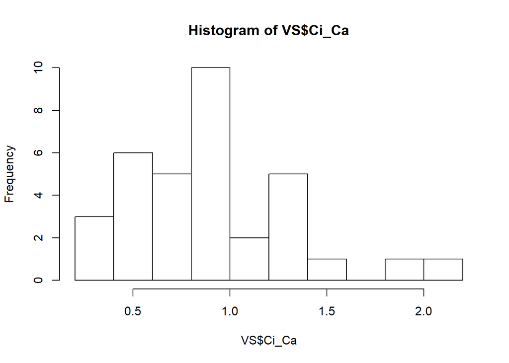

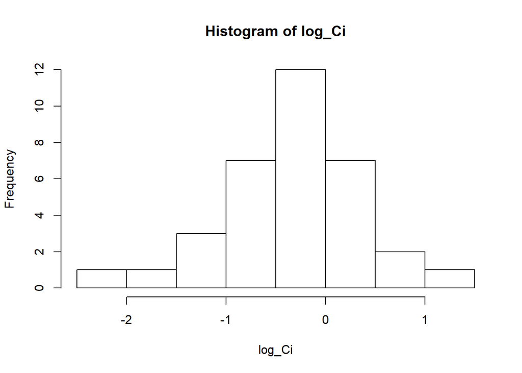

Df Sum Sq Mean Sq F value Pr(>F)  
Treatment 2 0.814 0.4068 0.922 0.4090  
Harvest 2 2.767 1.3834 3.136 0.0585 . Residuals 29 12.792 0.4411  
— Signif. codes: 0 ‘**’ 0.001 ’**’ 0.01 ’’ 0.05 ‘.’ 0.1 ‘’ 1 Tukey multiple comparisons of means 95% family-wise confidence level

Fit: aov(formula = log_Ci ~ Treatment + Harvest, data = VS)

$Treatment diff lwr upr p adj 8%-4% 0.33029742 -0.3393139 0.9999088 0.4522526 16%-4% 0.01506509 -0.6872292 0.7173594 0.9984539 16%-8% -0.31523233 -1.0175266 0.3870620 0.5166176

$Harvest diff lwr upr p adj H2-H1 -0.3352032 -0.9862964 0.315889922 0.4222629 H3-H1 -0.7699648 -1.5321033 -0.007826332 0.0473092 H3-H2 -0.4347616 -1.1528397 0.283316579 0.3079211

Tables of means Grand mean

-0.3284785

Treatment 4% 8% 16% -0.4495 -0.1192 -0.4344 rep 12.0000 12.0000 10.0000

Harvest H1 H2 H3 5.734e-04 -0.3346 -0.7694 rep 1.100e+01 15.0000 8.0000

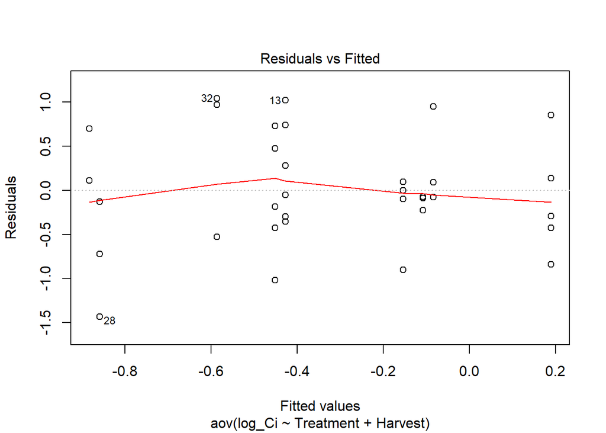

Levene’s Test for Homogeneity of Variance (center = median) Df F value Pr(>F) group 8 0.4425 0.8838 25

**Ci (umol mol) VE**

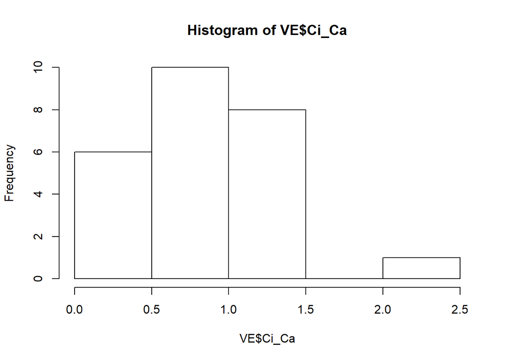

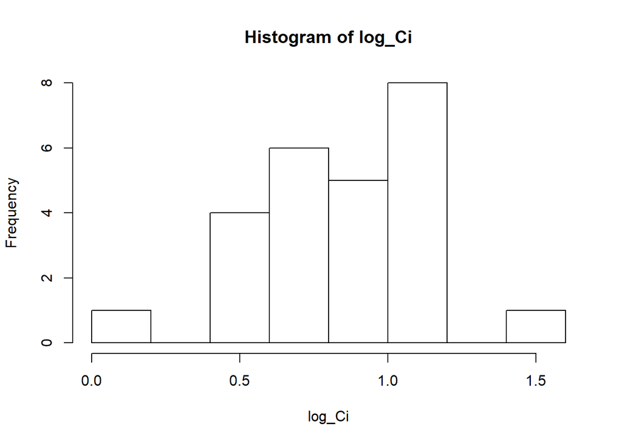

Df Sum Sq Mean Sq F value Pr(>F)  
Treatment 2 0.2456 0.12279 1.707 0.2056  
Harvest 1 0.2834 0.28341 3.941 0.0603 . Residuals 21 1.5103 0.07192  
— Signif. codes: 0 ‘**’ 0.001 ’**’ 0.01 ’’ 0.05 ‘.’ 0.1 ‘’ 1 Tukey multiple comparisons of means 95% family-wise confidence level

Fit: aov(formula = log_Ci ~ Treatment + Harvest, data = VE)

$Treatment diff lwr upr p adj 8%-4% 0.205891891 -0.1272230 0.5390068 0.2854319 16%-4% 0.006851222 -0.3429894 0.3566919 0.9986576 16%-8% -0.199040669 -0.5196749 0.1215936 0.2825170

$Harvest diff lwr upr p adj H3-H2 -0.211502 -0.4362068 0.01320266 0.0637203

Tables of means Grand mean

0.8484257

Treatment 4% 8% 16% 0.7639 0.9698 0.7707 rep 7.0000 10.0000 8.0000

Harvest H2 H3 0.9415 0.73 rep 14.0000 11.00

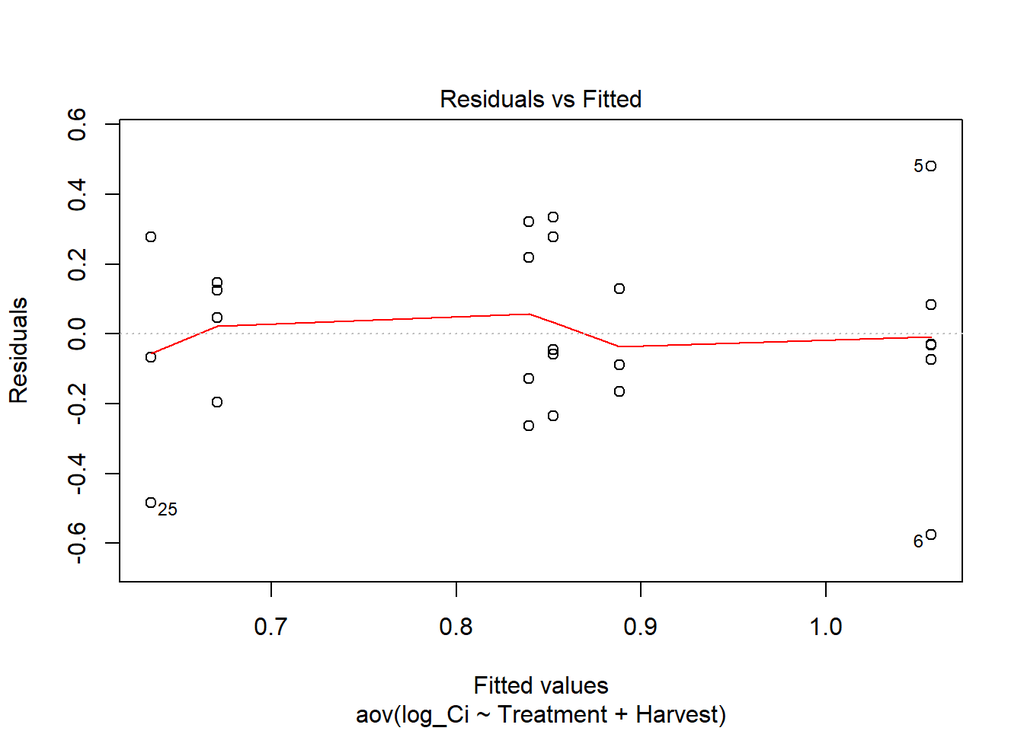

Levene’s Test for Homogeneity of Variance (center = median) Df F value Pr(>F) group 5 0.4412 0.8142 19  
**Amax (umol m-2 s-1) VS**

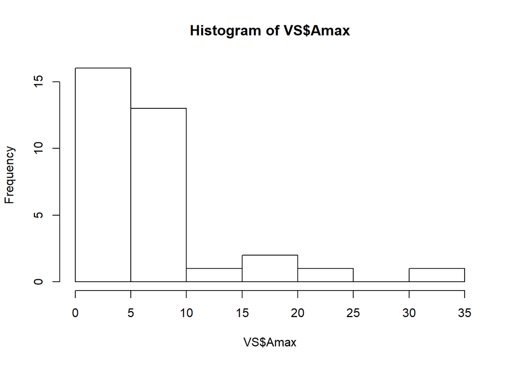

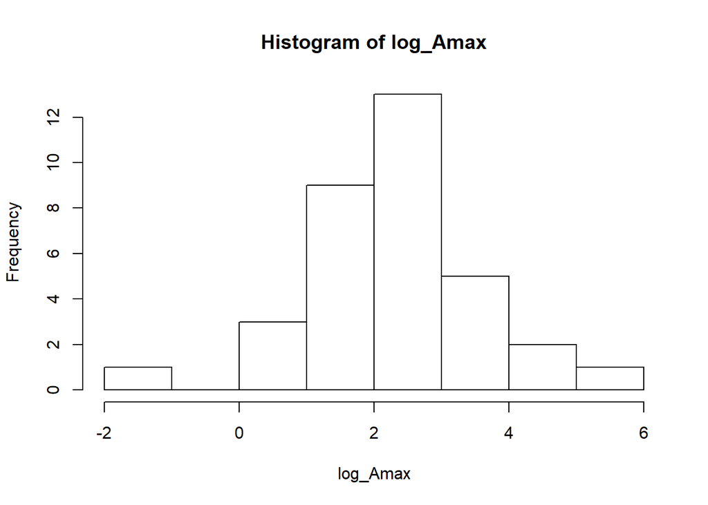

Df Sum Sq Mean Sq F value Pr(>F) Treatment 2 3.89 1.946 1.321 0.282 Harvest 2 3.35 1.675 1.137 0.335 Residuals 29 42.71 1.473  
Tukey multiple comparisons of means 95% family-wise confidence level

Fit: aov(formula = log_Amax ~ Treatment + Harvest, data = VS)

$Treatment diff lwr upr p adj 8%-4% -0.1657564 -1.389292 1.0577787 0.9402887 16%-4% -0.8095561 -2.092811 0.4736984 0.2796761 16%-8% -0.6437997 -1.927054 0.6394548 0.4404247

$Harvest diff lwr upr p adj H2-H1 0.6827310 -0.5069672 1.8724291 0.3454422 H3-H1 0.1743243 -1.2182794 1.5669279 0.9487739 H3-H2 -0.5084067 -1.8205019 0.8036886 0.6093831

Tables of means Grand mean

2.264795

Treatment 4% 8% 16% 2.561 2.396 1.752 rep 12.000 12.000 10.000

Harvest H1 H2 H3 1.923 2.605 2.097 rep 11.000 15.000 8.000

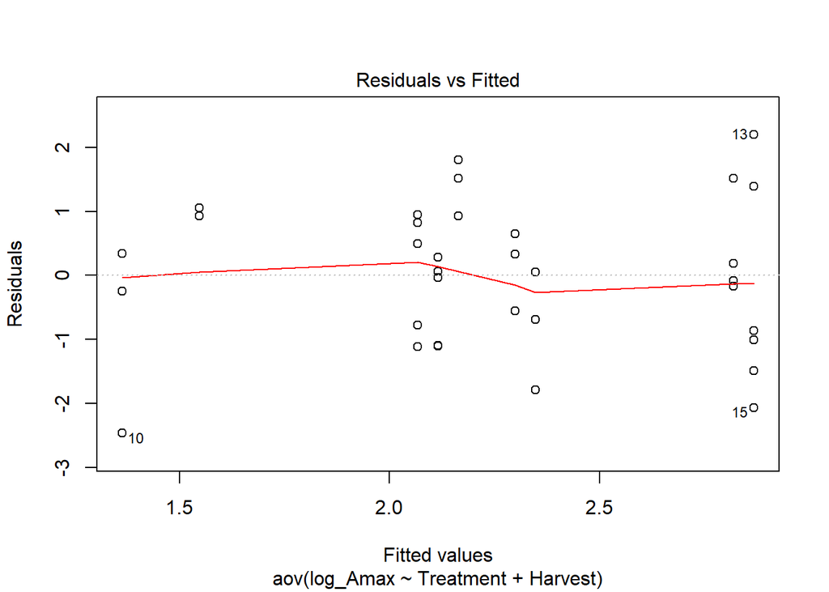

Levene’s Test for Homogeneity of Variance (center = median) Df F value Pr(>F) group 8 0.7137 0.6774 25  
**Amax (umol m-2 s-1) VE**

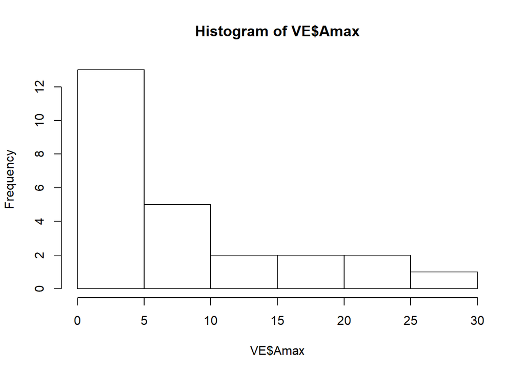

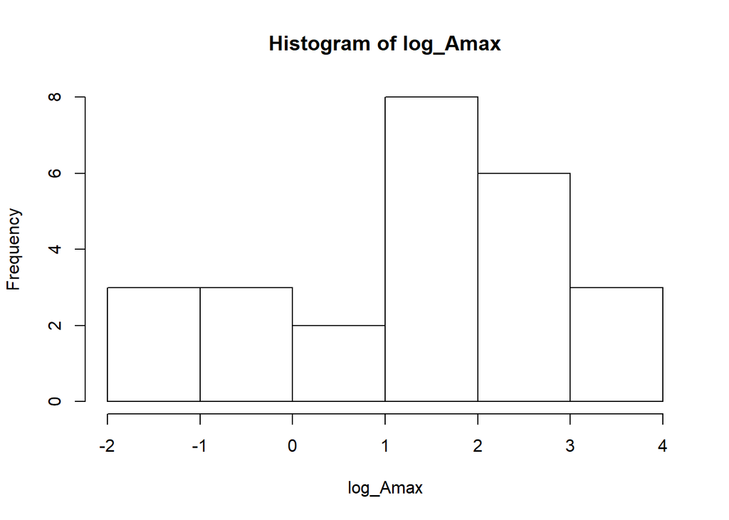

Df Sum Sq Mean Sq F value Pr(>F)  
Treatment 2 1.987 0.994 0.703 0.506556  
Harvest 1 22.154 22.154 15.664 0.000719 *** Residuals 21 29.701 1.414  
— Signif. codes: 0 ‘**’ 0.001 ’**’ 0.01 ’’ 0.05 ‘.’ 0.1 ‘’ 1 Tukey multiple comparisons of means 95% family-wise confidence level

Fit: aov(formula = log_Amax ~ Treatment + Harvest, data = VE)

$Treatment diff lwr upr p adj 8%-4% -0.05078461 -1.5280120 1.426443 0.9958697 16%-4% 0.57294847 -0.9784506 2.124348 0.6273031 16%-8% 0.62373307 -0.7981476 2.045614 0.5211987

$Harvest diff lwr upr p adj H3-H2 -1.869946 -2.866419 -0.8734735 0.00082

Tables of means Grand mean

1.29378

Treatment 4% 8% 16% 1.131 1.08 1.704 rep 7.000 10.00 8.000

Harvest H2 H3 2.117 0.2466 rep 14.000 11.0000

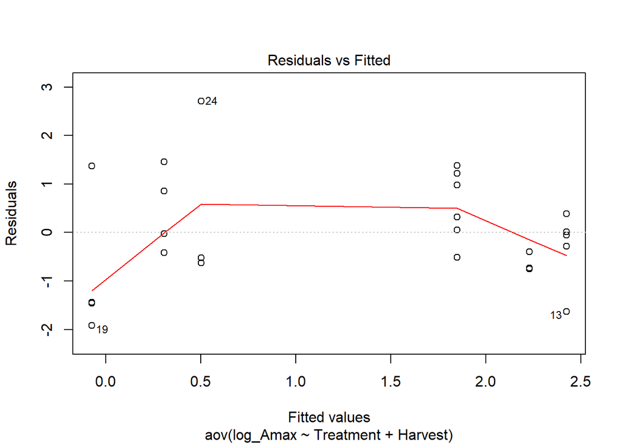

Levene’s Test for Homogeneity of Variance (center = median) Df F value Pr(>F) group 5 0.4644 0.7979 19  
**V.sieberiana LSA (mm2)**

|  | Df | Sum Sq | Mean Sq | F value | Pr(>F) |
| --- | --- | --- | --- | --- | --- |
| Treatment | 2 | 0.16 | 0.08 | 3.91 | 0.0314 |
| Harvest | 2 | 0.10 | 0.05 | 2.53 | 0.0968 |
| Residuals | 29 | 0.58 | 0.02 |  |  |

**V.sieberiana Ci:Ca**

|  | Df | Sum Sq | Mean Sq | F value | Pr(>F) |
| --- | --- | --- | --- | --- | --- |
| Treatment | 2 | 0.81 | 0.41 | 0.92 | 0.4090 |
| Harvest | 2 | 2.77 | 1.38 | 3.14 | 0.0585 |
| Residuals | 29 | 12.79 | 0.44 |  |  |

**V.sieberiana Amax (umol m-2 s-1)**

|  | Df | Sum Sq | Mean Sq | F value | Pr(>F) |
| --- | --- | --- | --- | --- | --- |
| Treatment | 2 | 3.89 | 1.95 | 1.32 | 0.2823 |
| Harvest | 2 | 3.35 | 1.67 | 1.14 | 0.3346 |
| Residuals | 29 | 42.71 | 1.47 |  |  |

**V.erioloba LSA (mm2)**

|  | Df | Sum Sq | Mean Sq | F value | Pr(>F) |
| --- | --- | --- | --- | --- | --- |
| Treatment | 2 | 0.00 | 0.00 | 0.10 | 0.9040 |
| Harvest | 1 | 0.02 | 0.02 | 1.20 | 0.2861 |
| Residuals | 21 | 0.42 | 0.02 |  |  |

**V.erioloba Ci:Ca**

|  | Df | Sum Sq | Mean Sq | F value | Pr(>F) |
| --- | --- | --- | --- | --- | --- |
| Treatment | 2 | 0.25 | 0.12 | 1.71 | 0.2056 |
| Harvest | 1 | 0.28 | 0.28 | 3.94 | 0.0603 |
| Residuals | 21 | 1.51 | 0.07 |  |  |

**V.erioloba Amax (umol m-2 s-1)**

|  | Df | Sum Sq | Mean Sq | F value | Pr(>F) |
| --- | --- | --- | --- | --- | --- |
| Treatment | 2 | 1.99 | 0.99 | 0.70 | 0.5066 |
| Harvest | 1 | 22.15 | 22.15 | 15.66 | 0.0007 |
| Residuals | 21 | 29.70 | 1.41 |  |  |

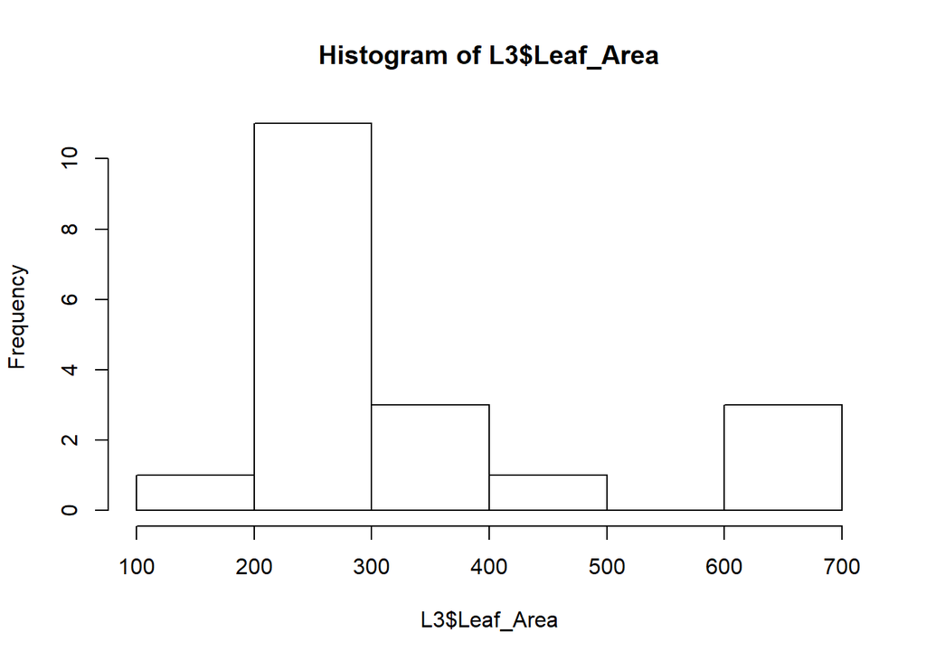

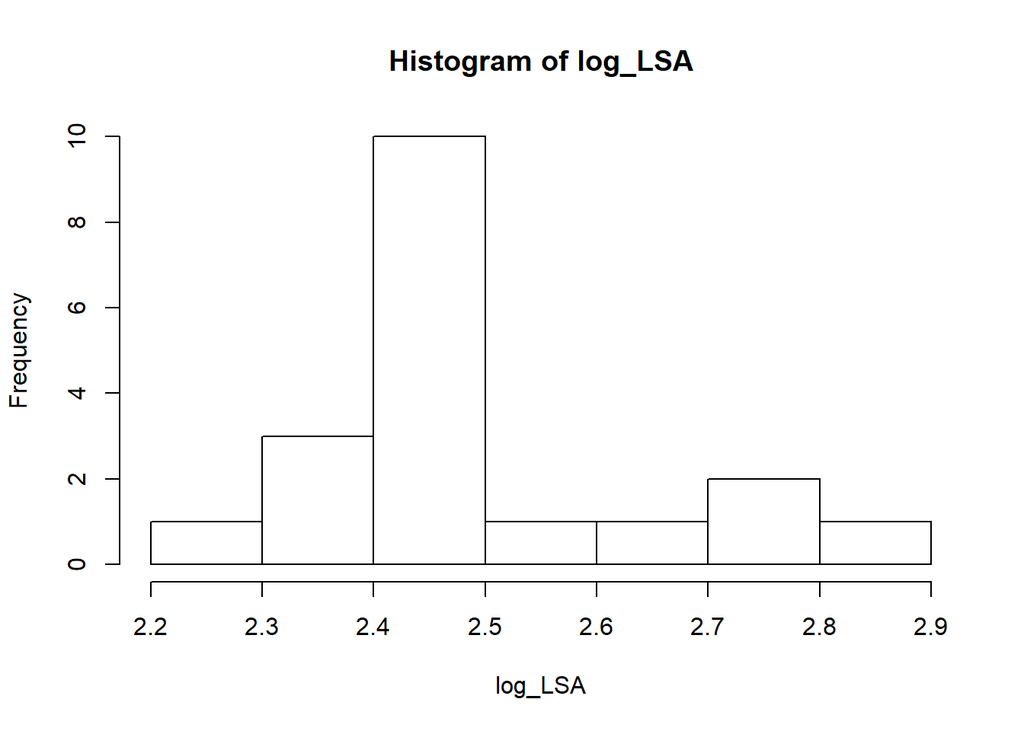

Df Sum Sq Mean Sq F value Pr(>F) Treatment 2 0.0238 0.01192 0.436 0.655 Species 1 0.0280 0.02796 1.023 0.328 Residuals 15 0.4099 0.02733  
Tukey multiple comparisons of means 95% family-wise confidence level

Fit: aov(formula = log_LSA ~ Treatment + Species, data = L3)

$Treatment diff lwr upr p adj 8%-4% 0.08096896 -0.1485439 0.3104819 0.6386435 16%-4% 0.05598032 -0.1954385 0.3073991 0.8335676 16%-8% -0.02498865 -0.2764074 0.2264301 0.9640137

$Species diff lwr upr p adj VE-VS -0.07767245 -0.2413922 0.08604729 0.3279509

Tables of means Grand mean

2.495575

Treatment 4% 8% 16% 2.451 2.532 2.507 rep 7.000 7.000 5.000

Species VS VE 2.541 2.463 rep 8.000 11.000

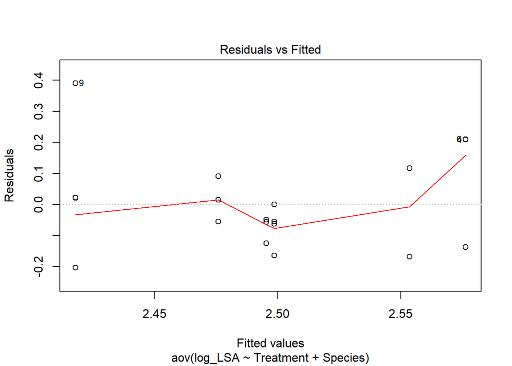

Levene’s Test for Homogeneity of Variance (center = median) Df F value Pr(>F) group 5 0.6484 0.6678 13

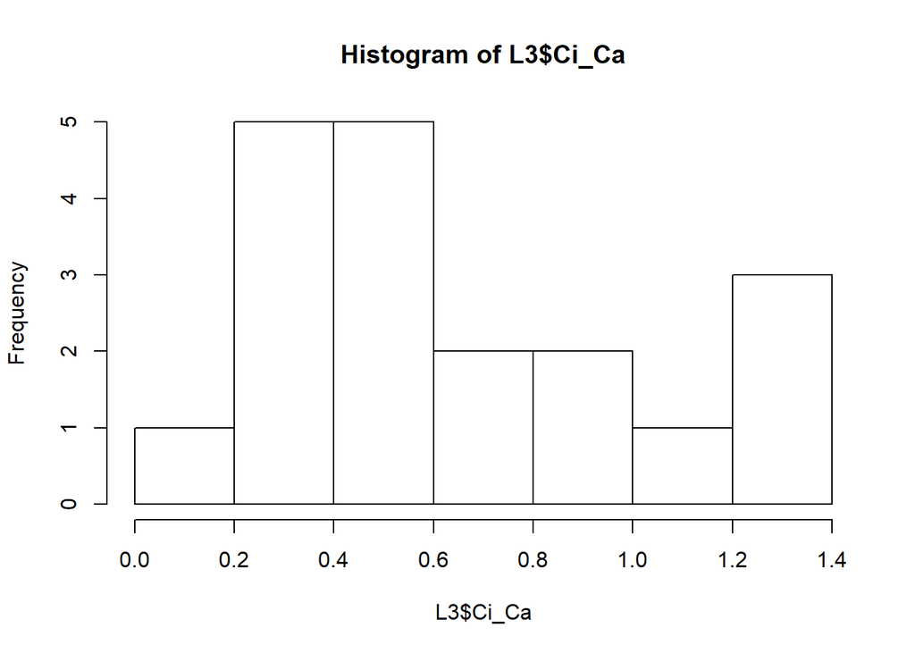

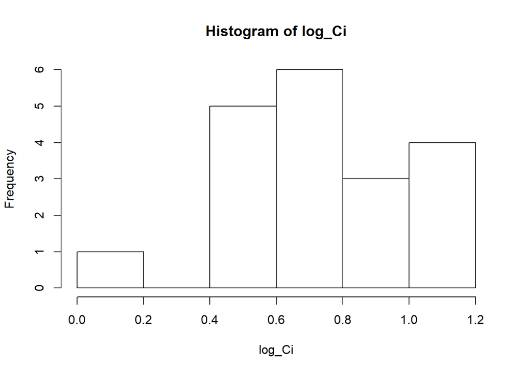

Df Sum Sq Mean Sq F value Pr(>F) Treatment 2 0.3262 0.16308 2.626 0.105 Species 1 0.0291 0.02906 0.468 0.504 Residuals 15 0.9315 0.06210  
Tukey multiple comparisons of means 95% family-wise confidence level

Fit: aov(formula = log_Ci ~ Treatment + Species, data = L3)

$Treatment diff lwr upr p adj 8%-4% 0.27850114 -0.06748852 0.6244908 0.1254090 16%-4% 0.01741667 -0.36159603 0.3964294 0.9921803 16%-8% -0.26108448 -0.64009717 0.1179282 0.2066747

$Species diff lwr upr p adj VE-VS -0.07918818 -0.325995 0.1676186 0.5044811

Tables of means Grand mean

0.756682

Treatment 4% 8% 16% 0.6495 0.928 0.6669 rep 7.0000 7.000 5.0000